# Problem statement

In this competitive world where IT operations are happening round the clock 24 hours, every organization yearns for quickly resolving encountered incidents to have no or minimal business impact.  
IT leverages incident management process to achieve this objective which after analyzing the type of the incident assign it to the respective groups to resolve the incident.  
In this Capstone project, the goal is to build a classifier that can classify the tickets by analyzing text.

Details about the data and dataset files are given in below link,  
https://drive.google.com/file/d/1OZNJm81JXucV3HmZroMq6qCT2m7ez7IJ

# Installing Prerequisite Libraries

```python
#Translation APIs for data present in languages other than English
!pip install langdetect
!pip install googletrans
```

```
     |████████████████████████████████| 983kB 8.4MB/s
     |████████████████████████████████| 61kB 4.5MB/s
     |████████████████████████████████| 51kB 4.9MB/s
     |████████████████████████████████| 1.0MB 8.6MB/s
     |████████████████████████████████| 71kB 8.0MB/s
     |████████████████████████████████| 61kB 8.0MB/s
```

# Importing Libraries

```python
# Data Handling
import pandas as pd

# Data Visualization
import matplotlib.pyplot as plt
import seaborn as sns

# Numerical calculation
import numpy as np

# Utilities
from time import time
from wordcloud import WordCloud, STOPWORDS
import os
import warnings
warnings.filterwarnings('ignore')
%matplotlib inline

# Tensorflow
import tensorflow as tf

# Traditional Modeling
from sklearn.model_selection import train_test_split, GridSearchCV
from sklearn.cluster import MiniBatchKMeans, KMeans
from sklearn.decomposition import PCA
from sklearn.feature_extraction.text import CountVectorizer, TfidfTransformer, TfidfVectorizer
from sklearn import preprocessing
from sklearn.naive_bayes import MultinomialNB
from sklearn.metrics  import accuracy_score, classification_report, confusion_matrix, homogeneity_score, silhouette_score, roc_auc_score, precision_score, recall_score, roc_curve, auc
from sklearn import model_selection, svm
from sklearn.ensemble import RandomForestClassifier, AdaBoostClassifier
from sklearn.model_selection import StratifiedKFold
from sklearn.linear_model import LogisticRegression
import sklearn.metrics as metrics
from sklearn.metrics import roc_curve
from sklearn.metrics import roc_auc_score

# Sequential Modeling
from keras.layers import Input
from keras.models import Sequential
from keras.layers import Dense, Embedding, LSTM, Dropout, Bidirectional, GlobalMaxPool1D, SpatialDropout1D, GRU
from keras.utils.np_utils import to_categorical
from keras.preprocessing.text import Tokenizer
from keras.preprocessing.sequence import pad_sequences
from keras.callbacks import ModelCheckpoint, EarlyStopping
from keras.callbacks import ReduceLROnPlateau

from collections import OrderedDict, Counter

# NLP toolkits
import gensim
import gensim.corpora as corpora
from gensim.utils import simple_preprocess
from gensim.parsing import preprocessing
from gensim.test.utils import common_texts
from gensim.models.doc2vec import Doc2Vec, TaggedDocument
from gensim.models.phrases import Phraser
from gensim.models import Phrases, CoherenceModel

import re

import string
from string import punctuation as punc

# NLP toolkits
import nltk
from nltk.corpus import stopwords
from nltk.tokenize import word_tokenize
from nltk.util import ngrams
from nltk.util import ngrams
from spacy.lang.en import English


#Translation
from textblob import TextBlob
from tqdm import tqdm
import googletrans
from googletrans import Translator

from langdetect import detect, DetectorFactory

from google.colab import drive
```

# Mounting Drive and read file

```python
drive.mount('/content/drive/')
```

```python
import os
path = '/content/drive/My Drive/Projects'
os.chdir(path)
```

```python
!pwd
```

```
/content/drive/My Drive/Projects
```

```python
df = pd.read_excel('input_data.xlsx')
```

# Understanding of Data

```python
df.head()
```

|  | Short description | Description | Caller | Assignment group |
| --- | --- | --- | --- | --- |
| 0 | login issue | -verified user details.(employee# & manager na... | spxjnwir pjlcoqds | GRP_0 |
| 1 | outlook | \r\n\r\nreceived from: hmjdrvpb.komuaywn@gmail... | hmjdrvpb komuaywn | GRP_0 |
| 2 | cant log in to vpn | \r\n\r\nreceived from: eylqgodm.ybqkwiam@gmail... | eylqgodm ybqkwiam | GRP_0 |
| 3 | unable to access hr_tool page | unable to access hr_tool page | xbkucsvz gcpydteq | GRP_0 |
| 4 | skype error | skype error | owlgqjme qhcozdfx | GRP_0 |

The dataset consists of four variables. The summary explanation is given as below:  
1) Short Description: This is a text column. It contains generic word combinations to describe the issue that has been logged by the user. Have null values.  
2) Description: This is a text column. It has the detail description of the ticket. It contains unformatted, junk, multilanguage data. Have null values  
3) Caller: This is a text column. It contains the name of the caller Doesn’t have null values  
4) Assignment Group: The group/ level number to which the tickets were assigned to. This is our target variable. Doesn’t have null values.

```python
df.info()
```

```
<class 'pandas.core.frame.DataFrame'>
RangeIndex: 8500 entries, 0 to 8499
Data columns (total 4 columns):
 #   Column             Non-Null Count  Dtype
---  ------             --------------  -----
 0   Short description  8492 non-null   object
 1   Description        8499 non-null   object
 2   Caller             8500 non-null   object
 3   Assignment group   8500 non-null   object
dtypes: object(4)
memory usage: 265.8+ KB
```

Dataset has total 8500 rows and 4 variables/columns.  
1 Target variable - Assignment Group  
3 independent variables - Short description, Description, Caller  
All Variables are of type object containing textual information.

```python
df.isnull().sum()
```

```
Short description    8
Description          1
Caller               0
Assignment group     0
dtype: int64
```

Column Description has 1 Null value  
Short Description has 8 Null values.  
Caller and Assignment group doesn't have any NULL values  
Let's check which all index in the dataset has null values

```python
# Find index of NaN values
SD_nan_index = df.loc[pd.isna(df["Short description"]), :].index
Desc_nan_index = df.loc[pd.isna(df['Description']),:].index
print('Short description null at index ', SD_nan_index)
print('Short description null at index ', Desc_nan_index)
```

```
Short description null at index  Int64Index([2604, 3383, 3906, 3910, 3915, 3921, 3924, 4341], dtype='int64')
Short description null at index  Int64Index([4395], dtype='int64')
```

```python
#Fill 'Short decsription' and 'Description' field entries that have null with word "the"
df['Description'].fillna(value='the', inplace=True)
df['Short description'].fillna(value='the', inplace=True)
```

```python
#Verify the null values again
df.isnull().sum()
```

```
Short description    0
Description          0
Caller               0
Assignment group     0
dtype: int64
```

```python
#Converting all rows to String
df['Short description']=df['Short description'].apply(str)
df['Description']=df['Description'].apply(str)
df['Caller']=df['Caller'].apply(str)
```

# EDA - Let's Visualize the Data distributrion

## Let's look at the distribution of our dataset based on Individual features

### Dataset Distribution by "Assignment Group"

```python
df.describe()
```

|  | Short description | Description | Caller | Assignment group |
| --- | --- | --- | --- | --- |
| count | 8500 | 8500 | 8500 | 8500 |
| unique | 7482 | 7817 | 2950 | 74 |
| top | password reset | the | bpctwhsn kzqsbmtp | GRP_0 |
| freq | 38 | 57 | 810 | 3976 |

Password reset is one of the most occuring tickets which reflects in the Short description column.  
The top occuring Description in the dataset is 'the', it is meaningless and we have to deal with it.  
There are 74 unique assignment groups for the tickets to be assigned  
Also we can see the top caller is 'bpctwhsn kzqsbmtp' and top or most frequent assignment group is GRP_0

```python
TargetClass = df['Assignment group'].value_counts()
TargetClass.describe()
```

```
count      74.000000
mean      114.864865
std       465.747516
min         1.000000
25%         5.250000
50%        26.000000
75%        84.000000
max      3976.000000
Name: Assignment group, dtype: float64
```

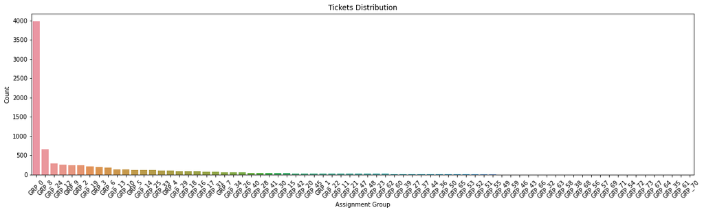

```python
plt.subplots(figsize = (20,5))

sns.countplot(x='Assignment group', data=df,order = df['Assignment group'].value_counts().index)
plt.xlabel('Assignment Group')
plt.ylabel('Count')
plt.xticks(rotation=45)
plt.title('Tickets Distribution')

plt.show()
```

The above data shows that the dataset is highly imbalanced based on 'Assignment Group' and it would have large impact on our Classification Model Accuracy.  
Observations:

1. There are 74 Groups in all. The Target class distribution is extremely skewed.
2. GRP_0 has the most number of assignments (3976) accounting for ~50% of the data.
3. There are some groups with 1 ticket assignment as well.  
   We could merge all groups with small entries to a group to reduce the imbalance in the target. This may reduce the imbalance to some extent.

#### Merge groups with small entries to a group to reduce the imbalance in the target class.

```python
# Group the tickets count < 50 as GRP_A
dfG = pd.DataFrame(df['Assignment group'].value_counts())
dfG = dfG.T
dfG
```

|  | GRP_0 | GRP_8 | GRP_24 | GRP_12 | GRP_9 | GRP_2 | GRP_19 | GRP_3 | GRP_6 | GRP_13 | GRP_10 | GRP_5 | GRP_14 | GRP_25 | GRP_33 | GRP_4 | GRP_29 | GRP_18 | GRP_16 | GRP_17 | GRP_31 | GRP_7 | GRP_34 | GRP_26 | GRP_40 | GRP_28 | GRP_41 | GRP_15 | GRP_30 | … |
| --- | --- | --- | --- | --- | --- | --- | --- | --- | --- | --- | --- | --- | --- | --- | --- | --- | --- | --- | --- | --- | --- | --- | --- | --- | --- | --- | --- | --- | --- | --- |
| Assignment group | 3976 | 661 | 289 | 257 | 252 | 241 | 215 | 200 | 184 | 145 | 140 | 129 | 118 | 116 | 107 | 100 | 97 | 88 | 85 | 81 | 69 | 68 | 62 | 56 | 45 | 44 | 40 | 39 | 39 | … |

```python
df['Count'] = df.apply(lambda row: dfG[row['Assignment group']] , axis=1)
df.loc[df['Count'] <= 50 , "Assignment group"] = "GRP_A"
```

#### Lets visualize no.of tickets in each Assignment group in pie chart format

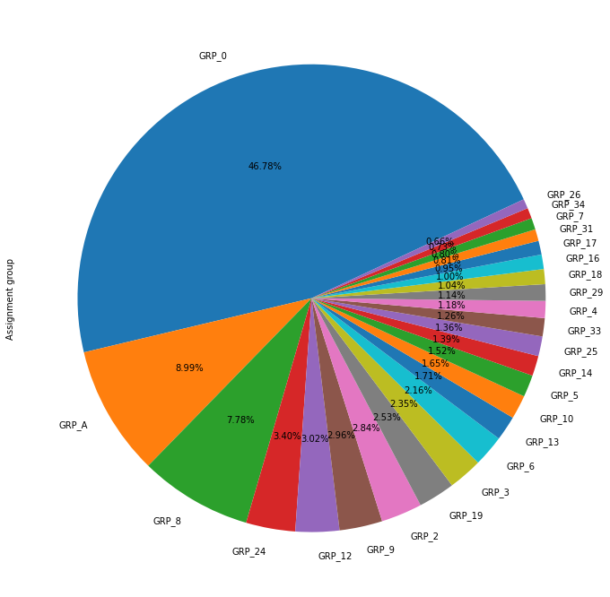

```python
plt.figure(figsize=(20,12))
df["Assignment group"].value_counts().plot.pie(autopct='%1.2f%%', fontsize=10, startangle=25)
```

The dataset consists of 74 unique groups with GRP_0 holding the maximum distribution of around 47%.  
Other major groups are GRP_A and GRP_8 holding around 8.99% and 7.78%

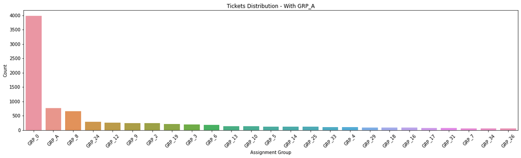

```python
plt.subplots(figsize = (20,5))

sns.countplot(x='Assignment group', data=df,order = df['Assignment group'].value_counts().index)
plt.xlabel('Assignment Group')
plt.ylabel('Count')
plt.xticks(rotation=45)
plt.title('Tickets Distribution - With GRP_A')

plt.show()
```

### Dataset Distribution by "Caller"

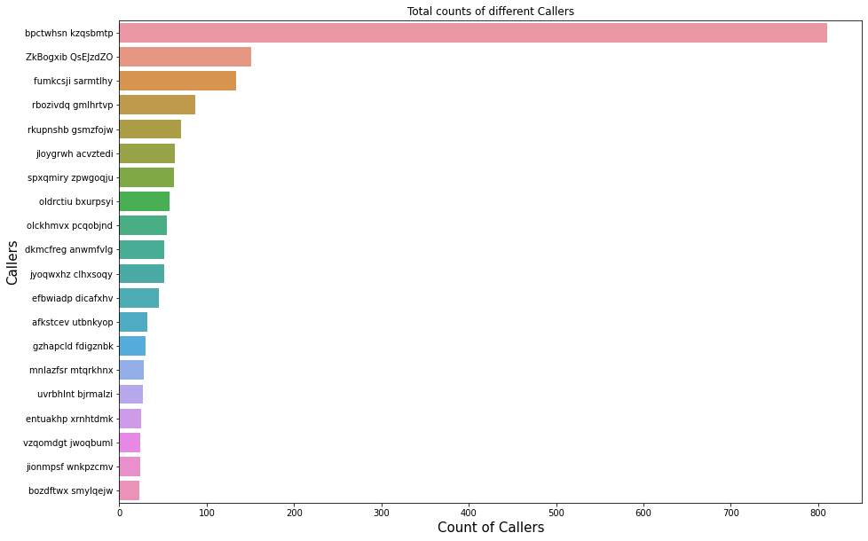

```python
fig, (ax1) = plt.subplots(1,1, figsize=(15,10))

x = df.groupby(['Caller']).size().sort_values(ascending=False).head(20)
sns.barplot(x, x.index, ax=ax1)
plt.title('Total counts of different Callers')
plt.gca().set_xlabel('Count of Callers',fontsize=15)
plt.gca().set_ylabel('Callers',fontsize=15)
```

" **bpctwhsn kzqsbmtp** " is the end user who has reported maximum number of tickets. So we assume, it has relationship towards prediction of Assignment group classification.

**Lets see the top 10 callers in raising tickets**

```python
top_callers = df.groupby(['Caller']).size().nlargest(10)
print(top_callers)
```

```
Caller
bpctwhsn kzqsbmtp    810
ZkBogxib QsEJzdZO    151
fumkcsji sarmtlhy    134
rbozivdq gmlhrtvp     87
rkupnshb gsmzfojw     71
jloygrwh acvztedi     64
spxqmiry zpwgoqju     63
oldrctiu bxurpsyi     57
olckhmvx pcqobjnd     54
dkmcfreg anwmfvlg     51
dtype: int64
```

**Lets check top 5 callers for each of the top 5 Assignment groups**

```python
top_c = df['Caller'].groupby(df['Assignment group']).value_counts()
grp_caller =pd.DataFrame(top_c.groupby(level=0).nlargest(5).reset_index(level=0, drop=True))
multy_caller = grp_caller[grp_caller.Caller.duplicated()]
grp_caller.head(25)
```

| Assignment group | Caller | Caller |
| --- | --- | --- |
| GRP_0 | fumkcsji sarmtlhy | 132 |
|  | rbozivdq gmlhrtvp | 86 |
|  | olckhmvx pcqobjnd | 54 |
|  | efbwiadp dicafxhv | 45 |
|  | mfeyouli ndobtzpw | 13 |
| GRP_10 | bpctwhsn kzqsbmtp | 60 |
|  | ihfkwzjd erbxoyqk | 6 |
|  | dizquolf hlykecxa | 5 |
|  | gnasmtvx cwxtsvkm | 3 |
|  | hlrmufzx qcdzierm | 3 |
| GRP_12 | oldrctiu bxurpsyi | 13 |
|  | rkupnshb gsmzfojw | 12 |
|  | jyoqwxhz clhxsoqy | 11 |
|  | spxqmiry zpwgoqju | 11 |
|  | jloygrwh acvztedi | 9 |
| GRP_13 | nuhfwplj ojcwxser | 6 |
|  | bpctwhsn kzqsbmtp | 4 |
|  | fmqubnvs kcxpeyiv | 3 |
|  | jwqyxbzs adpvilqu | 3 |
|  | tqfnalpj qyoscnge | 3 |
| GRP_14 | jyoqwxhz clhxsoqy | 12 |
|  | rkupnshb gsmzfojw | 9 |
|  | dkmcfreg anwmfvlg | 7 |
|  | iavozegx jpcudyfi | 6 |
|  | jloygrwh acvztedi | 6 |

**Identifying the groups with max tickets from Top caller - "bpctwhsn kzqsbmtp"**

```python
df[df['Caller']=='bpctwhsn kzqsbmtp']['Assignment group'].value_counts()
```

```
GRP_8     362
GRP_9     153
GRP_5      96
GRP_6      89
GRP_10     60
GRP_A      33
GRP_12      8
GRP_13      4
GRP_18      3
GRP_29      1
GRP_14      1
Name: Assignment group, dtype: int64
```

GRP_8 and GRP_9 has the max tickets from this user

Let's see what all type of issues group 8 and group 9 are resolving

```python
#Group by ShortDescription and Group
dfSDG = df.groupby(['Short description','Assignment group']).size().sort_values(ascending=False).reset_index()

dfSDG[dfSDG['Assignment group']=='GRP_8']['Short description'].head(8)
```

```
51     job Job_3028 failed in job_scheduler at: 08/24...
119                abended job in job_scheduler: Job_593
129    job SID_41arc2 failed in job_scheduler at: 08/...
131    abended job in job_scheduler: bk_hana_SID_62_e...
132    abended job in job_scheduler: bk_hana_SID_62_e...
134             abended job in job_scheduler: SID_37hoti
135    job SID_38hotf failed in job_scheduler at: 09/...
136    abended job in job_scheduler: bkbackup_tool_re...
Name: Short description, dtype: object
```

```python
#Group by ShortDescription and Group
dfSDG = df.groupby(['Short description','Assignment group']).size().sort_values(ascending=False).reset_index()

dfSDG[dfSDG['Assignment group']=='GRP_9']['Short description'].head(8)
```

```
46                abended job in job_scheduler: Job_1148
81                abended job in job_scheduler: Job_1141
105               abended job in job_scheduler: Job_1142
107               abended job in job_scheduler: Job_2114
127               abended job in job_scheduler: Job_1320
142               abended job in job_scheduler: Job_1305
177                          update of ae to bw and hana
374    i am getting this error when trying to open a ...
Name: Short description, dtype: object
```

We could see maximum incidents raised by “bpctwhsn kzqsbmtp” user and most of the issue are Job Failure related.  
We assume the person may be from Operations team raising incidents for L2/L3 team.

### Dataset Distribution by "Short Description"

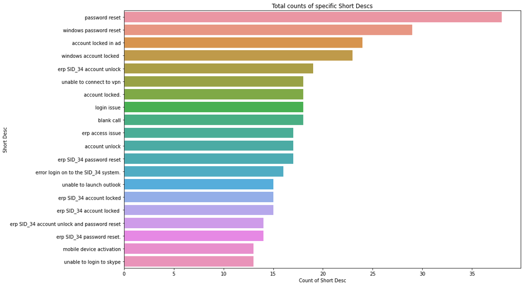

```python
fig, (ax1) = plt.subplots(1,1, figsize=(15,10))

x = df['Short description'].value_counts()[:20]
sns.barplot(x, x.index, ax=ax1)
plt.title('Total counts of specific Short Descs')
plt.gca().set_xlabel('Count of Short Desc')
plt.gca().set_ylabel('Short Desc')

plt.show()
```

Password reset is the type of issue, which is reported most of the time.

# Let's do some feature engineering, EDA and preprocessing of data

```python
df_en = df.copy()
```

```python
df_en.head()
```

|  | Short description | Description | Caller | Assignment group | Count |
| --- | --- | --- | --- | --- | --- |
| 0 | login issue | -verified user details.(employee# & manager na... | spxjnwir pjlcoqds | GRP_0 | 3976 |
| 1 | outlook | \r\n\r\nreceived from: hmjdrvpb.komuaywn@gmail... | hmjdrvpb komuaywn | GRP_0 | 3976 |
| 2 | cant log in to vpn | \r\n\r\nreceived from: eylqgodm.ybqkwiam@gmail... | eylqgodm ybqkwiam | GRP_0 | 3976 |
| 3 | unable to access hr_tool page | unable to access hr_tool page | xbkucsvz gcpydteq | GRP_0 | 3976 |
| 4 | skype error | skype error | owlgqjme qhcozdfx | GRP_0 | 3976 |

```python
#Converting all rows to String
df_en['Short description']=df_en['Short description'].apply(str)
df_en['Description']=df_en['Description'].apply(str)
df_en['Caller']=df_en['Caller'].apply(str)
```

## Removing Caller Name from Description Feature

```python
caller_list = df_en["Caller"].str.split(" ", n = 1, expand = True)

caller_fname = caller_list[0]
caller_lname = caller_list[1]

caller_fname_list = caller_fname.to_list()
caller_lname_list = caller_lname.to_list()

df_en.Description = df_en.Description.apply(lambda x: ' '.join([word for word in x.split() if word not in caller_fname_list]))
df_en.Description = df_en.Description.apply(lambda x: ' '.join([word for word in x.split() if word not in caller_lname_list]))
```

```python
#Let's combine all 3 independent attribute to 1
df_en['Final_Description'] = df_en['Short description'].str.cat(df_en['Description'],sep=" ")
#remove unnecessary spaces
df_en.Final_Description = df_en.Final_Description.apply(lambda x: x.strip())
```

```python
#Remove non consecutive duplicates
df_en['Final_Description'] = (df_en['Final_Description'].str.split().apply(lambda x: OrderedDict.fromkeys(x).keys()).str.join(' '))
```

```python
df_en.head(4)
```

|  | Short description | Description | Caller | Assignment group | Count | Final_Description |
| --- | --- | --- | --- | --- | --- | --- |
| 0 | login issue | -verified user details.(employee# & manager na... | spxjnwir pjlcoqds | GRP_0 | 3976 | login issue -verified user details.(employee# ... |
| 1 | outlook | received from: hmjdrvpb.komuaywn@gmail.com hel... | hmjdrvpb komuaywn | GRP_0 | 3976 | outlook received from: hmjdrvpb.komuaywn@gmail... |
| 2 | cant log in to vpn | received from: eylqgodm.ybqkwiam@gmail.com hi ... | eylqgodm ybqkwiam | GRP_0 | 3976 | cant log in to vpn received from: eylqgodm.ybq... |
| 3 | unable to access hr_tool page | unable to access hr_tool page | xbkucsvz gcpydteq | GRP_0 | 3976 | unable to access hr_tool page |

## As all 3 independent attributes are merged into 1 column, let's remove those columns from dataframe

```python
#As all 3 independent attributes are merged into 1 column, let's remove those columns from dataframe
df_en.drop(['Short description','Description','Caller'], axis=1, inplace=True)
df_en.head()
```

|  | Assignment group | Final_Description |
| --- | --- | --- |
| 0 | GRP_0 | login issue -verified user details.(employee# ... |
| 1 | GRP_0 | outlook received from: hmjdrvpb.komuaywn@gmail... |
| 2 | GRP_0 | cant log in to vpn received from: eylqgodm.ybq... |
| 3 | GRP_0 | unable to access hr_tool page |
| 4 | GRP_0 | skype error |

## Extract some Text features such as:

```
Number of words
Number of characters
Number of stopwords
Number of special characters
Number of numerics
Number of uppercase words
sentiment analysis
Non English Descriptions
and so on...
```

```python
import re
import numpy as np
import nltk
import gensim
stop_words = gensim.parsing.preprocessing.STOPWORDS
```

### WordCloud with Stopwords

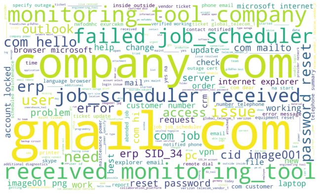

```python
#Word Cloud
text = " ".join(review for review in df_en['Final_Description'])
wordcloud = WordCloud(width = 2500, height = 1500, stopwords=stop_words, background_color="white").generate(text)

# Display the generated image:
# the matplotlib way:
plt.figure(figsize=(18,7))
plt.imshow(wordcloud, interpolation='bilinear')
plt.axis("off")
plt.show()
```

### Basic text Analysis

```python
#df_en.Description=='nan'
def missing_val(text):
  if text=='nan':
    output='True'
  else:
    output='False'
  return output
```

```python
def get_sentiment(text):
  sentiment = TextBlob(text).sentiment
  return sentiment[0]
```

```python
translator = Translator()
languages = googletrans.LANGUAGES
```

```python
DetectorFactory.seed = 0
```

```python
def count_regexp_occ(regexp='', text=None):
    return len(re.findall(regexp, text))
```

```python
def txtAnalysis(data, column):
  data['word_count'] = data[column].apply(lambda x : len(x.split(" ")))
  data['char_count'] = data[column].str.len()
  data['word_density'] = data['word_count'] / (data['char_count'] + 1)
  data['punc_count'] = data[column].apply(lambda x : len([a for a in x if a in punc]))
  data['stopwords'] = data[column].apply(lambda x: len([x for x in str(x).split() if x in stop_words]))
  data['numerics'] = data[column].apply(lambda x: len([x for x in x.split() if x.isdigit()]))
  data['upper'] = data[column].apply(lambda x: len([x for x in x.split() if x.isupper()]))
  data['sentiment'] = data[column].apply(lambda x : TextBlob(x).sentiment[0])
  data['is_null'] = data[column].apply(lambda x : missing_val(x))
  data['Language'] = data[column].apply(lambda x: detect(x))
  data['Language'] = data['Language'].apply(lambda x: languages[x].upper())
  data['num_symbols'] = data[column].apply(lambda x: sum(x.count(w) for w in '*#&$%?!'))
  data['num_unique_words'] = data[column].apply(lambda x: len(set(w for w in x.split())))
  data['num_smilies'] = data[column].apply(lambda x: sum(x.count(w) for w in (':-)', ':)', ';-)', ';)')))
  # Count number of \n
  data['num_slash_n'] = data[column].apply(lambda x: count_regexp_occ(r"\n", x))
  # Check for time stamp
  data['has_timestamp'] = data[column].apply(lambda x: count_regexp_occ(r"\d{2}|:\d{2}", x))
  # Check for http links
  data['has_http'] = data[column].apply(lambda x: count_regexp_occ(r"http[s]{0,1}://\S+", x))
  return data.head(8)
```

```python
df_eda = df_en.copy()
txtAnalysis(df_eda, 'Final_Description')
```

|  | Short description | Description | Caller | Assignment group | Count | Final_Description | word_count | char_count | word_density | punc_count | stopwords | numerics | upper | sentiment | is_null | Language | num_symbols | num_unique_words | num_smilies | num_slash_n | has_timestamp | has_http |
| --- | --- | --- | --- | --- | --- | --- | --- | --- | --- | --- | --- | --- | --- | --- | --- | --- | --- | --- | --- | --- | --- | --- |
| 0 | login issue | -verified user details.(employee# & manager na... | spxjnwir pjlcoqds | GRP_0 | 3976 | login issue -verified user details.(employee# ... | 28 | 183 | 0.152174 | 14 | 8 | 0 | 0 | 0.450000 | False | ENGLISH | 2 | 28 | 0 | 0 | 0 | 0 |
| 1 | outlook | received from: hmjdrvpb.komuaywn@gmail.com hel... | hmjdrvpb komuaywn | GRP_0 | 3976 | outlook received from: hmjdrvpb.komuaywn@gmail... | 24 | 177 | 0.134831 | 8 | 9 | 0 | 0 | 0.600000 | False | ENGLISH | 1 | 24 | 0 | 0 | 0 | 0 |
| 2 | cant log in to vpn | received from: eylqgodm.ybqkwiam@gmail.com hi ... | eylqgodm ybqkwiam | GRP_0 | 3976 | cant log in to vpn received from: eylqgodm.ybq... | 13 | 81 | 0.158537 | 4 | 6 | 0 | 0 | 1.000000 | False | ENGLISH | 0 | 13 | 0 | 0 | 0 | 0 |
| 3 | unable to access hr_tool page | unable to access hr_tool page | xbkucsvz gcpydteq | GRP_0 | 3976 | unable to access hr_tool page | 5 | 29 | 0.166667 | 1 | 1 | 0 | 0 | -0.500000 | False | ENGLISH | 0 | 5 | 0 | 0 | 0 | 0 |
| 4 | skype error | skype error | owlgqjme qhcozdfx | GRP_0 | 3976 | skype error | 2 | 11 | 0.166667 | 0 | 0 | 0 | 0 | 0.000000 | False | NORWEGIAN | 0 | 2 | 0 | 0 | 0 | 0 |
| 5 | unable to log in to engineering tool and skype | unable to log in to engineering tool and skype | eflahbxn ltdgrvkz | GRP_0 | 3976 | unable to log in engineering tool and skype | 8 | 43 | 0.181818 | 0 | 3 | 0 | 0 | -0.500000 | False | ENGLISH | 0 | 8 | 0 | 0 | 0 | 0 |
| 6 | event: critical:HostName_221.company.com the v... | event: critical:HostName_221.company.com the v... | jyoqwxhz clhxsoqy | GRP_A | 31 | event: critical:HostName_221.company.com the v... | 12 | 179 | 0.066667 | 20 | 4 | 1 | 0 | 0.000000 | False | ENGLISH | 0 | 12 | 0 | 0 | 8 | 0 |
| 7 | ticket_no1550391- employment status - new non-... | ticket_no1550391- employment status - new non-... | eqzibjhw ymebpoih | GRP_0 | 3976 | ticket_no1550391- employment status - new non-... | 9 | 74 | 0.120000 | 7 | 0 | 0 | 0 | 0.136364 | False | ENGLISH | 0 | 9 | 0 | 0 | 3 | 0 |

```python
df_eda.describe()
```

|  | Count | word_count | char_count | word_density | punc_count | stopwords | numerics | upper | sentiment | num_symbols | num_unique_words | num_smilies | num_slash_n | has_timestamp | has_http |
| --- | --- | --- | --- | --- | --- | --- | --- | --- | --- | --- | --- | --- | --- | --- | --- |
| count | 8500.000000 | 8500.000000 | 8500.000000 | 8500.000000 | 8500.000000 | 8500.000000 | 8500.000000 | 8500.000000 | 8500.000000 | 8500.000000 | 8500.000000 | 8500.000000 | 8500.0 | 8500.000000 | 8500.0 |
| mean | 1977.831294 | 23.175765 | 173.730824 | 0.139794 | 14.133294 | 6.078118 | 0.559882 | 0.099529 | -0.043817 | 0.420118 | 23.175765 | 0.001529 | 0.0 | 5.031176 | 0.0 |
| std | 1878.984522 | 38.950473 | 335.435350 | 0.032013 | 50.896100 | 7.960117 | 6.751471 | 0.451924 | 0.278579 | 2.692823 | 38.950473 | 0.039080 | 0.0 | 31.995243 | 0.0 |
| min | 1.000000 | 1.000000 | 1.000000 | 0.013514 | 0.000000 | 0.000000 | 0.000000 | 0.000000 | -1.000000 | 0.000000 | 1.000000 | 0.000000 | 0.0 | 0.000000 | 0.0 |
| 25% | 145.000000 | 6.000000 | 44.000000 | 0.117021 | 1.000000 | 1.000000 | 0.000000 | 0.000000 | -0.133333 | 0.000000 | 6.000000 | 0.000000 | 0.0 | 0.000000 | 0.0 |
| 50% | 661.000000 | 12.000000 | 103.000000 | 0.141026 | 5.000000 | 3.000000 | 0.000000 | 0.000000 | 0.000000 | 0.000000 | 12.000000 | 0.000000 | 0.0 | 1.000000 | 0.0 |
| 75% | 3976.000000 | 28.000000 | 198.000000 | 0.160654 | 11.000000 | 9.000000 | 0.000000 | 0.000000 | 0.000000 | 0.000000 | 28.000000 | 0.000000 | 0.0 | 6.000000 | 0.0 |
| max | 3976.000000 | 981.000000 | 8753.000000 | 0.500000 | 2296.000000 | 85.000000 | 271.000000 | 7.000000 | 1.000000 | 156.000000 | 981.000000 | 1.000000 | 0.0 | 1016.000000 | 0.0 |

```python
df_eda.sort_values(by='word_count', ascending=False).head(5)
```

|  | Short description | Description | Caller | Assignment group | Count | Final_Description | word_count | char_count | word_density | punc_count | stopwords | numerics | upper | sentiment | is_null | Language | num_symbols | num_unique_words | num_smilies | num_slash_n | has_timestamp | has_http |
| --- | --- | --- | --- | --- | --- | --- | --- | --- | --- | --- | --- | --- | --- | --- | --- | --- | --- | --- | --- | --- | --- | --- |
| 4089 | security incidents - ( sw #in33895560 ) : mage... | source ip : 172.20.10.37 , 208.211.136.158 sys... | ugyothfz ugrmkdhx | GRP_2 | 241 | security incidents - ( sw #in33895560 ) : mage... | 981 | 8753 | 0.112063 | 572 | 67 | 271 | 1 | -0.004900 | False | ENGLISH | 28 | 981 | 0 | 0 | 941 | 0 |
| 4087 | security incidents - ( sw #in33895560 ) : mage... | source ip : 172.20.10.37 , 208.211.136.158 sys... | ugyothfz ugrmkdhx | GRP_A | 19 | security incidents - ( sw #in33895560 ) : mage... | 980 | 8749 | 0.112000 | 571 | 67 | 271 | 1 | -0.004900 | False | ENGLISH | 28 | 980 | 0 | 0 | 941 | 0 |
| 5433 | security incidents - ( #in33765965 ) : possibl... | source ip :10.40.6.221 system name :rqxl851722... | gzhapcld fdigznbk | GRP_2 | 241 | security incidents - ( #in33765965 ) : possibl... | 960 | 8009 | 0.119850 | 2296 | 7 | 218 | 2 | -0.285511 | False | CATALAN | 80 | 960 | 0 | 0 | 1016 | 0 |
| 7997 | security incidents - ( sw #in33544563 ) : poss... | source ip : 45.25.35.0499 system name : lpal95... | ugyothfz ugrmkdhx | GRP_2 | 241 | security incidents - ( sw #in33544563 ) : poss... | 838 | 7016 | 0.119424 | 720 | 75 | 119 | 2 | -0.054466 | False | ENGLISH | 27 | 838 | 0 | 0 | 596 | 0 |
| 8002 | security incidents - ( sw #in33544563 ) : poss... | source ip : 45.25.35.0499 system name : lpal95... | ugyothfz ugrmkdhx | GRP_A | 25 | security incidents - ( sw #in33544563 ) : poss... | 838 | 7016 | 0.119424 | 720 | 75 | 119 | 2 | -0.054466 | False | ENGLISH | 27 | 838 | 0 | 0 | 596 | 0 |

```python
print("Maximum number of words used in the description: ",df_eda.word_count.max())
```

```
Maximum number of words used in the description:  981
```

```python
print("Maximun number of characters used in the description: ",df_eda.char_count.max())
```

```
Maximun number of characters used in the description:  8753
```

```python
print("Maximun number of punctuations used in the description: ",df_eda.punc_count.max())
```

```
Maximun number of punctuations used in the description:  2296
```

```python
print("Maximun number of stopwords used in the description: ",df_eda.stopwords.max())
```

```
Maximun number of stopwords used in the description:  85
```

## Let's visualize the features that we extracted above

### Word Density Distribution

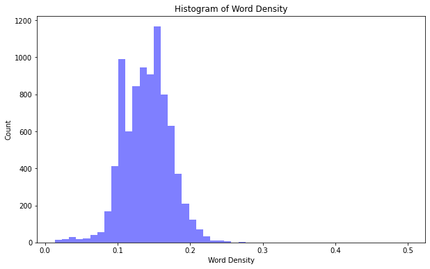

```python
num_bins = 50
plt.figure(figsize=(10,6))
n, bins, patches = plt.hist(df_eda.word_density, num_bins, facecolor='blue', alpha=0.5)
plt.xlabel('Word Density')
plt.ylabel('Count')
plt.title('Histogram of Word Density')
```

### Punctuation count Distribution

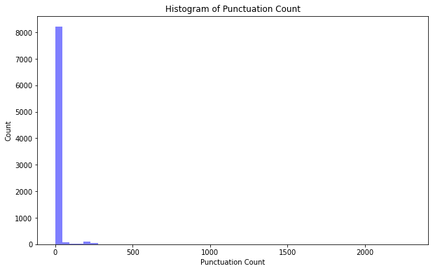

```python
num_bins = 50
plt.figure(figsize=(10,6))
n, bins, patches = plt.hist(df_eda.punc_count, num_bins, facecolor='blue', alpha=0.5)
plt.xlabel('Punctuation Count')
plt.ylabel('Count')
plt.title('Histogram of Punctuation Count')
plt.show();
```

### Stop Words count Distribution

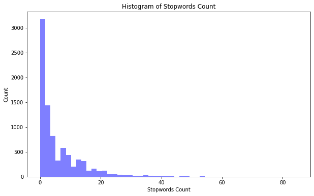

```python
num_bins = 50
plt.figure(figsize=(10,6))
n, bins, patches = plt.hist(df_eda.stopwords, num_bins, facecolor='blue', alpha=0.5)
plt.xlabel('Stopwords Count')
plt.ylabel('Count')
plt.title('Histogram of Stopwords Count')
plt.show();
```

### Most Common words

```python
Counter(" ".join(df_eda['Final_Description']).split() ).most_common(20)
```

```
[('to', 3316),
 ('in', 2642),
 ('the', 2559),
 ('from:', 2445),
 ('received', 2329),
 ('is', 1937),
 ('not', 1688),
 ('on', 1592),
 ('and', 1545),
 ('please', 1524),
 ('for', 1482),
 ('i', 1261),
 ('a', 1164),
 ('of', 1052),
 ('it', 1017),
 ('job', 997),
 ('erp', 969),
 ('monitoring_tool@company.com', 961),
 ('password', 937),
 ('unable', 870)]
```

# Data Preprocessing

```python
dfTicket =  df_eda.copy()
dfTicket.head()
```

|  | Short description | Description | Caller | Assignment group | Count | Final_Description | word_count | char_count | word_density | punc_count | stopwords | numerics | upper | sentiment | is_null | Language | num_symbols | num_unique_words | num_smilies | num_slash_n | has_timestamp | has_http |
| --- | --- | --- | --- | --- | --- | --- | --- | --- | --- | --- | --- | --- | --- | --- | --- | --- | --- | --- | --- | --- | --- | --- |
| 0 | login issue | -verified user details.(employee# & manager na... | spxjnwir pjlcoqds | GRP_0 | 3976 | login issue -verified user details.(employee# ... | 28 | 183 | 0.152174 | 14 | 8 | 0 | 0 | 0.45 | False | ENGLISH | 2 | 28 | 0 | 0 | 0 | 0 |
| 1 | outlook | received from: hmjdrvpb.komuaywn@gmail.com hel... | hmjdrvpb komuaywn | GRP_0 | 3976 | outlook received from: hmjdrvpb.komuaywn@gmail... | 24 | 177 | 0.134831 | 8 | 9 | 0 | 0 | 0.60 | False | ENGLISH | 1 | 24 | 0 | 0 | 0 | 0 |
| 2 | cant log in to vpn | received from: eylqgodm.ybqkwiam@gmail.com hi ... | eylqgodm ybqkwiam | GRP_0 | 3976 | cant log in to vpn received from: eylqgodm.ybq... | 13 | 81 | 0.158537 | 4 | 6 | 0 | 0 | 1.00 | False | ENGLISH | 0 | 13 | 0 | 0 | 0 | 0 |
| 3 | unable to access hr_tool page | unable to access hr_tool page | xbkucsvz gcpydteq | GRP_0 | 3976 | unable to access hr_tool page | 5 | 29 | 0.166667 | 1 | 1 | 0 | 0 | -0.50 | False | ENGLISH | 0 | 5 | 0 | 0 | 0 | 0 |
| 4 | skype error | skype error | owlgqjme qhcozdfx | GRP_0 | 3976 | skype error | 2 | 11 | 0.166667 | 0 | 0 | 0 | 0 | 0.00 | False | NORWEGIAN | 0 | 2 | 0 | 0 | 0 | 0 |

```python
regexList = ['From:(.*)\r\n',
 'IiNnCc[0-9]*',
 'ticket[_]*[\\s]*[0-9]*',
 'Sent:(.*)\r\n',
 'Received:(.*)\r\n',
 'To:(.*)\r\n',
 'CC:(.*)\r\n',
 '\\[cid:(.*)]',
 'https?:[^\\]\n\r]+',
 'Subject:',
 '[0-9][\\-0–90-9 ]+',# phones
 '[0-9]',# numbers
 '[^a-zA-z 0-9]+',# anything that is not a letter
 '[\r\n]',# single letters
 ' [a-zA-Z] ',  # two-letter words
 '  ', # double spaces
 '^[_a-z0-9-]+(\\.[_a-z0-9-]+)*@[a-z0-9-]+(\\.[a-z0-9-]+)*(\\.[a-z]{2,4})$',
 '[\\w\\d\\-\\_\\.]+ @ [\\w\\d\\-\\_\\.]+',
 'Subject:',
 '[^a-zA-Z]',
 '\\S+@\\S+',# emails
 "\b\d{1,3}\.\d{1,3}\.\d{1,3}\.\d{1,3}\b" #IP Address
 ]
```

```python
#Remove punctuations
def remove_punctuations(text):
    for punctuation in string.punctuation:
          text = text.replace(punctuation, ' ')
    return text
```

```python
def removeString(data, regex):
    return data.str.lower().str.replace(regex.lower(), ' ')
```

```python
#Translate tickets to English
def fn_translate(desc, lang):
  try:
    if lang == 'ENGLISH':
        return desc
    else:
        return translator.translate(desc).text
  except:
    return desc
```

```python
def textPreprocessing(data,column):
  print("updating all cases to lower cases:")
  data[column] = data[column].apply(lambda x: " ".join(x.lower() for x in x.split()))
  print("Translating Non English to English:")
  data['EnglishDescription'] = data.apply(lambda x: fn_translate(x[column], x['Language']), axis=1)
  print("removing data using regular expression List:")
  for regex in regexList:
            data['EnglishDescription'] = removeString(data['EnglishDescription'], regex)
  print("removing stopwords:")
  data['EnglishDescription'] = data['EnglishDescription'].apply(lambda x: " ".join(x for x in x.split() if x not in stop_words))
  freq = pd.Series(' '.join(data['EnglishDescription']).split()).value_counts()[:20]
  print("removing top 20 Most common words:")
  data['EnglishDescription'] = data['EnglishDescription'].apply(lambda x: " ".join(x for x in x.split() if x not in freq))
  rare = pd.Series(' '.join(data['EnglishDescription']).split()).value_counts()[-20:]
  print("removing top 20 rare words ata using regular expression List:")
  data['EnglishDescription'] = data['EnglishDescription'].apply(lambda x: " ".join(x for x in x.split() if x not in rare))
  print("removing punctuations:")
  data['EnglishDescription'] = data['EnglishDescription'].apply(remove_punctuations)
  return data.head(8)
```

```python
dfTicket.head()
```

|  | Short description | Description | Caller | Assignment group | Count | Final_Description | word_count | char_count | word_density | punc_count | stopwords | numerics | upper | sentiment | is_null | Language | num_symbols | num_unique_words | num_smilies | num_slash_n | has_timestamp | has_http |
| --- | --- | --- | --- | --- | --- | --- | --- | --- | --- | --- | --- | --- | --- | --- | --- | --- | --- | --- | --- | --- | --- | --- |
| 0 | login issue | -verified user details.(employee# & manager na... | spxjnwir pjlcoqds | GRP_0 | 3976 | login issue -verified user details.(employee# ... | 28 | 183 | 0.152174 | 14 | 8 | 0 | 0 | 0.45 | False | ENGLISH | 2 | 28 | 0 | 0 | 0 | 0 |
| 1 | outlook | received from: hmjdrvpb.komuaywn@gmail.com hel... | hmjdrvpb komuaywn | GRP_0 | 3976 | outlook received from: hmjdrvpb.komuaywn@gmail... | 24 | 177 | 0.134831 | 8 | 9 | 0 | 0 | 0.60 | False | ENGLISH | 1 | 24 | 0 | 0 | 0 | 0 |
| 2 | cant log in to vpn | received from: eylqgodm.ybqkwiam@gmail.com hi ... | eylqgodm ybqkwiam | GRP_0 | 3976 | cant log in to vpn received from: eylqgodm.ybq... | 13 | 81 | 0.158537 | 4 | 6 | 0 | 0 | 1.00 | False | ENGLISH | 0 | 13 | 0 | 0 | 0 | 0 |
| 3 | unable to access hr_tool page | unable to access hr_tool page | xbkucsvz gcpydteq | GRP_0 | 3976 | unable to access hr_tool page | 5 | 29 | 0.166667 | 1 | 1 | 0 | 0 | -0.50 | False | ENGLISH | 0 | 5 | 0 | 0 | 0 | 0 |
| 4 | skype error | skype error | owlgqjme qhcozdfx | GRP_0 | 3976 | skype error | 2 | 11 | 0.166667 | 0 | 0 | 0 | 0 | 0.00 | False | NORWEGIAN | 0 | 2 | 0 | 0 | 0 | 0 |

```python
textPreprocessing(dfTicket,'Final_Description')
```

```
updating all cases to lower cases:
Translating Non English to English:
removing data using regular expression List:
removing stopwords:
removing top 20 Most common words:
removing top 20 rare words ata using regular expression List:
removing punctuations:
```

|  | Short description | Description | Caller | Assignment group | Count | Final_Description | word_count | char_count | word_density | punc_count | stopwords | numerics | upper | sentiment | is_null | Language | num_symbols | num_unique_words | num_smilies | num_slash_n | has_timestamp | has_http | EnglishDescription |
| --- | --- | --- | --- | --- | --- | --- | --- | --- | --- | --- | --- | --- | --- | --- | --- | --- | --- | --- | --- | --- | --- | --- | --- |
| 0 | login issue | -verified user details.(employee# & manager na... | spxjnwir pjlcoqds | GRP_0 | 3976 | login issue -verified user details.(employee# ... | 28 | 183 | 0.152174 | 14 | 8 | 0 | 0 | 0.450000 | False | ENGLISH | 2 | 28 | 0 | 0 | 0 | 0 | login verified details employee manager checke... |
| 1 | outlook | received from: hmjdrvpb.komuaywn@gmail.com hel... | hmjdrvpb komuaywn | GRP_0 | 3976 | outlook received from: hmjdrvpb.komuaywn@gmail... | 24 | 177 | 0.134831 | 8 | 9 | 0 | 0 | 0.600000 | False | ENGLISH | 1 | 24 | 0 | 0 | 0 | 0 | outlook hmjdrvpb komuaywn hello team meetings ... |
| 2 | cant log in to vpn | received from: eylqgodm.ybqkwiam@gmail.com hi ... | eylqgodm ybqkwiam | GRP_0 | 3976 | cant log in to vpn received from: eylqgodm.ybq... | 13 | 81 | 0.158537 | 4 | 6 | 0 | 0 | 1.000000 | False | ENGLISH | 0 | 13 | 0 | 0 | 0 | 0 | log vpn eylqgodm ybqkwiam hi best |
| 3 | unable to access hr_tool page | unable to access hr_tool page | xbkucsvz gcpydteq | GRP_0 | 3976 | unable to access hr_tool page | 5 | 29 | 0.166667 | 1 | 1 | 0 | 0 | -0.500000 | False | ENGLISH | 0 | 5 | 0 | 0 | 0 | 0 | hr page |
| 4 | skype error | skype error | owlgqjme qhcozdfx | GRP_0 | 3976 | skype error | 2 | 11 | 0.166667 | 0 | 0 | 0 | 0 | 0.000000 | False | NORWEGIAN | 0 | 2 | 0 | 0 | 0 | 0 | skype |
| 5 | unable to log in to engineering tool and skype | unable to log in to engineering tool and skype | eflahbxn ltdgrvkz | GRP_0 | 3976 | unable to log in engineering tool and skype | 8 | 43 | 0.181818 | 0 | 3 | 0 | 0 | -0.500000 | False | ENGLISH | 0 | 8 | 0 | 0 | 0 | 0 | log engineering skype |
| 6 | event: critical:HostName_221.company.com the v... | event: critical:HostName_221.company.com the v... | jyoqwxhz clhxsoqy | GRP_A | 31 | event: critical:hostname_221.company.com the v... | 12 | 179 | 0.066667 | 20 | 4 | 1 | 0 | 0.000000 | False | ENGLISH | 0 | 12 | 0 | 0 | 8 | 0 | event critical hostname value mountpoint thres... |
| 7 | ticket_no1550391- employment status - new non-... | ticket_no1550391- employment status - new non-... | eqzibjhw ymebpoih | GRP_0 | 3976 | ticket_no1550391- employment status - new non-... | 9 | 74 | 0.120000 | 7 | 0 | 0 | 0 | 0.136364 | False | ENGLISH | 0 | 9 | 0 | 0 | 3 | 0 | employment status new non employee enter |

### Most Common words after preprocessing

```python
counter = Counter(" ".join(dfTicket['EnglishDescription']).split() ).most_common(20)
counter
```

```
[('working', 651),
 ('help', 644),
 ('hello', 627),
 ('hostname', 607),
 ('network', 584),
 ('yes', 583),
 ('outlook', 549),
 ('need', 543),
 ('vendor', 525),
 ('login', 521),
 ('na', 506),
 ('power', 492),
 ('telecom', 481),
 ('message', 418),
 ('id', 406),
 ('outage', 401),
 ('hi', 398),
 ('phone', 397),
 ('able', 389),
 ('team', 382)]
```

#### Tokenization and Lemmatization

We performed basic cleaning of our dataset.  
Let's look into tokenization, N-grams and visualize how our dataset looks

```python
# Word tokenization
nlp = English()
```

```python
def tokenizeText(text):
  #  "nlp" Object is used to create documents with linguistic annotations.
  my_doc = nlp(text)
  # Create list of word tokens
  token_list = []
  for token in my_doc:
    token_list.append(token.text)
  return token_list
```

```python
nltk.download('punkt')
```

```
True
```

```python
dfTicket['Tokens'] = dfTicket['EnglishDescription'].apply(lambda x: tokenizeText(x))
```

```python
#Cleaning stop words after tokenization
cleanTokens = []
for col_desc in range(len(dfTicket.Tokens)):
  str_token = dfTicket.Tokens[col_desc]
  cleanTokens.append([w for w in str_token if w not in stop_words] )

dfTicket['Tokens'] = cleanTokens
```

```python
def lemmatizeText(text):
  text = ' '.join(map(str, text))
  # Implementing lemmatization
  lem = nlp(text)
  lemma_list = []
  # finding lemma for each word
  for word in lem:
    lemma_list.append(word.lemma_)
  return lemma_list
  #return list(set(lemma_list))
```

```python
dfTicket['LemmaWords'] = dfTicket['Tokens'].apply(lambda x: lemmatizeText(x))
```

#### Word Cloud after Lemmatization

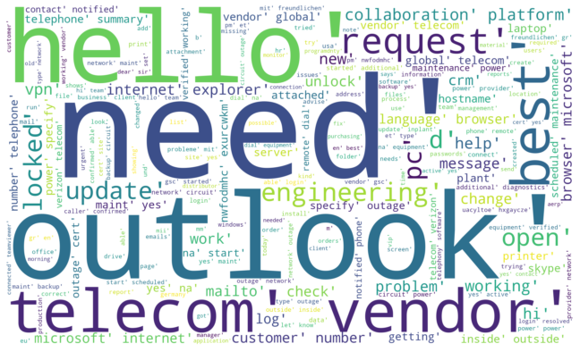

```python
#Word Cloud
text = ' '.join(map(str, dfTicket.LemmaWords))

wordcloud = WordCloud(width = 2500, height = 1500, background_color = 'white',stopwords=STOPWORDS).generate(text)

# Display the generated image:
# the matplotlib way:
plt.figure(figsize=(18,7))
plt.imshow(wordcloud, interpolation='bilinear')
plt.axis("off")
plt.show()
```

```python
print('Average count of chars per Description cell is {0:.0f}.'.format(dfTicket.groupby('Assignment group')['EnglishDescription'].count().mean()))
```

```
Average count of chars per Description cell is 340.
```

## Ngrams

```python
dfTicketngrams = dfTicket.copy()
```

```python
dfTicketngrams.head(5)
```

|  | Short description | Description | Caller | Assignment group | Count | Final_Description | word_count | char_count | word_density | punc_count | stopwords | numerics | upper | sentiment | is_null | Language | num_symbols | num_unique_words | num_smilies | num_slash_n | has_timestamp | has_http | EnglishDescription | Tokens | LemmaWords |
| --- | --- | --- | --- | --- | --- | --- | --- | --- | --- | --- | --- | --- | --- | --- | --- | --- | --- | --- | --- | --- | --- | --- | --- | --- | --- |
| 0 | login issue | -verified user details.(employee# & manager na... | spxjnwir pjlcoqds | GRP_0 | 3976 | login issue -verified user details.(employee# ... | 28 | 183 | 0.152174 | 14 | 8 | 0 | 0 | 0.45 | False | ENGLISH | 2 | 28 | 0 | 0 | 0 | 0 | login verified details employee manager checke... | [login, verified, details, employee, manager, ... | [login, verified, details, employee, manager, ... |
| 1 | outlook | received from: hmjdrvpb.komuaywn@gmail.com hel... | hmjdrvpb komuaywn | GRP_0 | 3976 | outlook received from: hmjdrvpb.komuaywn@gmail... | 24 | 177 | 0.134831 | 8 | 9 | 0 | 0 | 0.60 | False | ENGLISH | 1 | 24 | 0 | 0 | 0 | 0 | outlook hmjdrvpb komuaywn hello team meetings ... | [outlook, hmjdrvpb, komuaywn, hello, team, mee... | [outlook, hmjdrvpb, komuaywn, hello, team, mee... |
| 2 | cant log in to vpn | received from: eylqgodm.ybqkwiam@gmail.com hi ... | eylqgodm ybqkwiam | GRP_0 | 3976 | cant log in to vpn received from: eylqgodm.ybq... | 13 | 81 | 0.158537 | 4 | 6 | 0 | 0 | 1.00 | False | ENGLISH | 0 | 13 | 0 | 0 | 0 | 0 | log vpn eylqgodm ybqkwiam hi best | [log, vpn, eylqgodm, ybqkwiam, hi, best] | [log, vpn, eylqgodm, ybqkwiam, hi, best] |
| 3 | unable to access hr_tool page | unable to access hr_tool page | xbkucsvz gcpydteq | GRP_0 | 3976 | unable to access hr_tool page | 5 | 29 | 0.166667 | 1 | 1 | 0 | 0 | -0.50 | False | ENGLISH | 0 | 5 | 0 | 0 | 0 | 0 | hr page | [hr, page] | [hr, page] |
| 4 | skype error | skype error | owlgqjme qhcozdfx | GRP_0 | 3976 | skype error | 2 | 11 | 0.166667 | 0 | 0 | 0 | 0 | 0.00 | False | NORWEGIAN | 0 | 2 | 0 | 0 | 0 | 0 | skype | [skype] | [skype] |

```python
def get_top_ticketdesc_unigrams(corpus, n=None):
    vec = CountVectorizer(ngram_range=(1, 1)).fit(corpus)
    bag_of_words = vec.transform(corpus)
    sum_words = bag_of_words.sum(axis=0)
    words_freq = [(word, sum_words[0, idx]) for word, idx in vec.vocabulary_.items()]
    words_freq =sorted(words_freq, key = lambda x: x[1], reverse=True)
    print(words_freq)
    return words_freq[:n]
```

```
[('working', 651), ('help', 644), ('hello', 627), ('hostname', 607), ('network', 584), ('yes', 583), ('outlook', 549), ('need', 543), ('vendor', 525), ('login', 521), ('na', 506), ('power', 492), ('telecom', 481), ('message', 418), ('id', 406), ('outage', 401), ('hi', 398), ('phone', 397), ('able', …
```

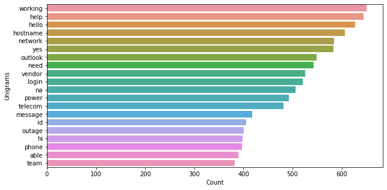

```python
plt.figure(figsize=(10,5))
top_unigrams=get_top_ticketdesc_unigrams(dfTicketngrams['EnglishDescription'])[:20]
x,y=map(list,zip(*top_unigrams))
sns.barplot(x=y,y=x)
plt.ylabel("Unigrams")
plt.xlabel("Count")
```

```python
def get_top_ticketdesc_bigrams(corpus, n=None):
    vec = CountVectorizer(ngram_range=(2, 2)).fit(corpus)
    bag_of_words = vec.transform(corpus)
    sum_words = bag_of_words.sum(axis=0)
    words_freq = [(word, sum_words[0, idx]) for word, idx in vec.vocabulary_.items()]
    words_freq =sorted(words_freq, key = lambda x: x[1], reverse=True)
    return words_freq[:n]
```

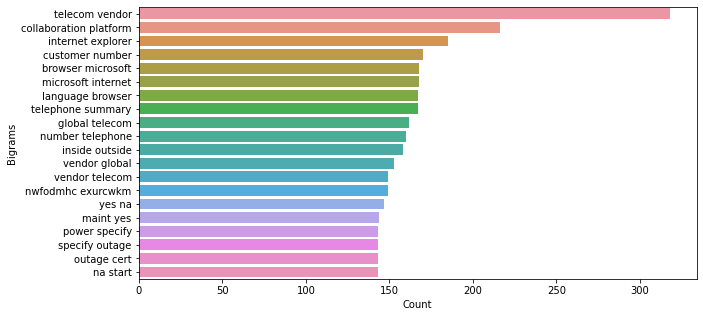

```python
plt.figure(figsize=(10,5))
top_bigrams=get_top_ticketdesc_bigrams(dfTicketngrams['EnglishDescription'])[:20]
x,y=map(list,zip(*top_bigrams))
sns.barplot(x=y,y=x)
plt.ylabel("Bigrams")
plt.xlabel("Count")
```

```python
def get_top_ticketdesc_trigrams(corpus, n=None):
    vec = CountVectorizer(ngram_range=(3, 3)).fit(corpus)
    bag_of_words = vec.transform(corpus)
    sum_words = bag_of_words.sum(axis=0)
    words_freq = [(word, sum_words[0, idx]) for word, idx in vec.vocabulary_.items()]
    words_freq =sorted(words_freq, key = lambda x: x[1], reverse=True)
    return words_freq[:n]
```

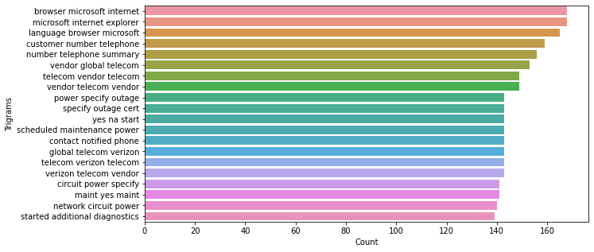

```python
plt.figure(figsize=(10,5))
top_trigrams=get_top_ticketdesc_trigrams(dfTicketngrams['EnglishDescription'])[:20]
x,y=map(list,zip(*top_trigrams))
sns.barplot(x=y,y=x)
plt.ylabel("Trigrams")
plt.xlabel("Count")
```

#### Create Corpus

```python
def listToString(s):
  str1 = " "
  for ele in s:
    str1 = str1 + " " + ele
  return str1
```

```python
def create_corpus(df):
    corpus=[]
    for desc in tqdm(df['LemmaString'].astype(str)):
        words=[word.lower() for word in word_tokenize(desc) if((word.isalpha()==1))] # & (word not in stop_words))]
        corpus.append(words)
    return corpus
```

```python
dfTicketngrams['LemmaString'] = dfTicketngrams['LemmaWords'].apply(lambda x: listToString(x))
corpus=create_corpus(dfTicketngrams)
```

```python
df1Ticketngrams = dfTicketngrams.copy()
corpus1=create_corpus(df1Ticketngrams)
```

```python
df2Ticketngrams = dfTicketngrams.copy()
corpus2=create_corpus(df1Ticketngrams)
```

# Topic Modeling

#### Latent Dirichlet Allocation(LDA)

It is a popular algorithm for topic modeling with excellent implementations in the Python’s Gensim package to extract the hidden topics from large volumes of text.It builds a topic per document model and words per topic model, modeled as Dirichlet distributions. Let's first use gensim to implement LDA and we are going to apply LDA to Description column and split them into different topics.  
The main inputs needed for doing LDA is:

- corpus
- dictionary of words with term frequency

```python
#To process the simple_process gensim package as input needed as string
combined_text=dfTicketngrams.LemmaString.values.tolist()
```

```python
combined_text[1]
```

```
'  outlook hmjdrvpb komuaywn hello team meetings skype meetings appearing calendar somebody advise correct kind'
```

```python
#Convert  Combined text from each sentense to the words. use of simple_process as it tokenize() internally

def sent_to_words(sentences):
    for sentence in sentences:
        yield(gensim.utils.simple_preprocess(str(sentence), deacc=True))  # deacc=True removes punctuations

data_words = list(sent_to_words(combined_text))
```

```python
print(data_words[1])
```

```
['outlook', 'hmjdrvpb', 'komuaywn', 'hello', 'team', 'meetings', 'skype', 'meetings', 'appearing', 'calendar', 'somebody', 'advise', 'correct', 'kind']
```

```python
# Build the bigram and trigram models
bigram = gensim.models.Phrases(data_words, min_count=5, threshold=100) # higher threshold fewer phrases.
trigram = gensim.models.Phrases(bigram[data_words], threshold=100)

# Faster way to get a sentence clubbed as a trigram/bigram
bigram_mod = gensim.models.phrases.Phraser(bigram)
trigram_mod = gensim.models.phrases.Phraser(trigram)
```

```python
print(bigram_mod[data_words[1]])
```

```
['outlook', 'hmjdrvpb', 'komuaywn', 'hello', 'team', 'meetings', 'skype', 'meetings', 'appearing', 'calendar', 'somebody', 'advise', 'correct', 'kind']
```

```python
# See trigram example
print(trigram_mod[bigram_mod[data_words[1]]])
```

```
['outlook', 'hmjdrvpb', 'komuaywn', 'hello', 'team', 'meetings', 'skype', 'meetings', 'appearing', 'calendar', 'somebody', 'advise', 'correct', 'kind']
```

```python
def make_bigrams(texts):
    return [bigram_mod[doc] for doc in texts]

def make_trigrams(texts):
    return [trigram_mod[bigram_mod[doc]] for doc in texts]
```

```python
# Form Bigrams
data_words_bigrams = make_bigrams(data_words)
```

```python
print(data_words_bigrams[1])
```

```
['outlook', 'hmjdrvpb', 'komuaywn', 'hello', 'team', 'meetings', 'skype', 'meetings', 'appearing', 'calendar', 'somebody', 'advise', 'correct', 'kind']
```

```python
# Create Dictionary
id2word = corpora.Dictionary(data_words_bigrams)

# Create Corpus from post clean data
texts = data_words_bigrams

# Term Document
corpus = [id2word.doc2bow(text) for text in texts]
```

```python
# View not human readable
print(corpus[:1])
```

```
[[(0, 1), (1, 1), (2, 1), (3, 1), (4, 1), (5, 2), (6, 1), (7, 1), (8, 1)]]
```

```python
#possible human redable
print([[(id2word[id], freq) for id, freq in cp] for cp in corpus[:1]])
```

```
[[('able', 1), ('advised_check', 1), ('caller_confirmed', 1), ('checked_ad', 1), ('details_employee', 1), ('login', 2), ('manager', 1), ('resolved', 1), ('verified', 1)]]
```

```python
def lemmatization(texts):
    """https://spacy.io/api/annotation"""
    texts_out = []
    for sent in texts:
        doc = nlp(" ".join(sent))
        texts_out.append([token.lemma_ for token in doc])
    return texts_out

data_lemmatized = lemmatization(data_words_bigrams)
```

```python
import gensim.corpora as corpora
from gensim.models.coherencemodel import CoherenceModel
from gensim.models.ldamodel import LdaModel
from gensim.corpora.dictionary import Dictionary
from numpy import array
```

```python
def compute_coherence_values(dictionary, corpus, texts, limit, start=2, step=1):
    coherence_values = []
    model_list = []
    for num_topics in range(start, limit, step):
        model=LdaModel(corpus=corpus, id2word=id2word, num_topics=num_topics, random_state=1)
        model_list.append(model)
        coherencemodel = CoherenceModel(model=model, texts=texts, dictionary=id2word, coherence='c_v')
        coherence_values.append(coherencemodel.get_coherence())
    return model_list, coherence_values
```

```python
np.random.seed(42)
model_list, coherence_values = compute_coherence_values(dictionary=id2word, corpus=corpus, texts=data_lemmatized, start=2, limit=15, step=1)
```

```python
# Show graph
import matplotlib.pyplot as plt
limit=15; start=2; step=1;
x = range(start, limit, step)
```

Topic Coherence is a useful metric for measuring the human interpretability of a given LDA topic model. Gensim's CoherenceModel allows Topic Coherence to be calculated for a given LDA model

```python
for m, cv in zip(x, coherence_values):
    print("Num Topics =", m, " has Coherence Value of", round(cv, 4))
```

```
Num Topics = 2  has Coherence Value of 0.4344
Num Topics = 3  has Coherence Value of 0.3483
Num Topics = 4  has Coherence Value of 0.5033
Num Topics = 5  has Coherence Value of 0.5071
Num Topics = 6  has Coherence Value of 0.4592
Num Topics = 7  has Coherence Value of 0.4794
Num Topics = 8  has Coherence Value of 0.4918
Num Topics = 9  has Coherence Value of 0.4626
Num Topics = 10  has Coherence Value of 0.4465
Num Topics = 11  has Coherence Value of 0.4357
Num Topics = 12  has Coherence Value of 0.4614
Num Topics = 13  has Coherence Value of 0.4809
Num Topics = 14  has Coherence Value of 0.4592
```

```python
coh = []
for cv in coherence_values:
    coh.append(round(cv, 4))

top = []
for m in x:
    top.append(m)
```

```python
#U-mass
coh = [abs(k) for k in coh]
cohd = [j-i for i,j in zip(coh[:-1],coh[1:])]
cohd = [abs(k) for k in cohd]
cohh = sorted(cohd,reverse=True)[:3]
b = set(cohh)
c = [i for i, item in enumerate(cohd) if item in cohh]
c = sorted(c)[:1]
res_list = [top[i+1] for i in c]
res_list = res_list[0]
n = res_list
print(n)
```

```
3
```

```python
optimal_model = model_list[2]
model_topics = optimal_model.show_topics(formatted=True)
print(optimal_model.print_topics(num_words=20))
```

```
[(0, '0.008*"hostname" + 0.006*"plant" + 0.005*"usa" + 0.005*"hello" + 0.004*"inside_outside" + 0.004*"need" + 0.004*"order" + 0.004*"server" + 0.004*"data" + 0.004*"check" + 0.004*"team" + 0.003*"connection" + 0.003*"management" + 0.003*"setup" + 0.003*"production" + 0.003*"help" + 0.003*"phone" + …
```

```python
#cv
cohd = [j-i for i,j in zip(coh[:-1],coh[1:])]
cohd = [ round(elem, 4) for elem in cohd ]

cohd = [abs(k) for k in cohd]
cohs = sorted(cohd)[:3]

b = set(cohs)
c = [i for i, item in enumerate(cohd) if item in b]
c = sorted(c)[:1]

res_list = [top[i] for i in c]
res_list = res_list[0]
n = res_list
print(n)
```

```
4
```

```python
from sklearn.feature_extraction.text import CountVectorizer
dfTicketngrams = dfTicketngrams.sort_values(by=['Assignment group'])
#count_vect = CountVectorizer(max_df=0.8, min_df=2)
count_vect = CountVectorizer()
doc_term_matrix = count_vect.fit_transform(dfTicketngrams['EnglishDescription'].values.astype('U'))
```

```python
from sklearn.decomposition import LatentDirichletAllocation

LDA = LatentDirichletAllocation(n_components=n, random_state=42)
LDA.fit(doc_term_matrix)


topic_values = LDA.transform(doc_term_matrix)
topic_values.shape
```

[output not shown]

```python
dfTicketngrams['Cluster'] = topic_values.argmax(axis=1)
dfTicketngrams.head()
```

[output not shown]

```python
dfTicketngrams.Cluster.value_counts()
```

[output not shown]

```python
dfTicketngrams.head(50)
```

[output not shown]

```python
split_data = dfTicketngrams["EnglishDescription"].str.split(" ")
processed_data = split_data.to_list()
gensim_dictionary = corpora.Dictionary(processed_data)
gensim_corpus = [gensim_dictionary.doc2bow(token, allow_update=True) for token in processed_data]
```

```python
lda_model = gensim.models.ldamodel.LdaModel(gensim_corpus, num_topics=n, id2word=gensim_dictionary, passes=20)
```

```python
def format_topics_sentences(ldamodel, corpus, texts,labels):
    # Init output
    sent_topics_df = pd.DataFrame()

    for i, row in enumerate(ldamodel[corpus]):
        row = sorted(row, key=lambda x: (x[1]), reverse=True)
        for j, (topic_num, prop_topic) in enumerate(row):
            if j == 0:  # => dominant topic
                wp = ldamodel.show_topic(topic_num)
                topic_keywords = ", ".join([word for word, prop in wp])
                sent_topics_df = sent_topics_df.append(pd.Series([int(topic_num)+1, round(prop_topic,4),topic_keywords,labels[i]]), ignore_index=True)
            else:
                break
    sent_topics_df.columns = ['Dominant_Topic', 'Perc_Contribution','topic_keywords','labels']
    contents = pd.Series(texts)
    return(sent_topics_df)


df_topic_sents_keywords2 = format_topics_sentences(ldamodel=lda_model, corpus=gensim_corpus, texts=dfTicketngrams["EnglishDescription"],labels=dfTicketngrams["Assignment group"])
df_topic_sents_keywords2
```

[output not shown]

8500 rows × 4 columns

```python
df_topic_sents_keywords2.Dominant_Topic.value_counts()
```

```
5.0    1987
6.0    1530
3.0    1515
1.0    1095
2.0    1061
7.0     705
4.0     607
Name: Dominant_Topic, dtype: int64
```

```python
ccc =dfTicketngrams.EnglishDescription.values.tolist()
print(len(ccc))
conv = lambda i : i or ''
res = [conv(i) for i in ccc]

print(len(res))
vectorizer = CountVectorizer()
X = vectorizer.fit_transform(res)
ccc=[]
res=[]
```

```
8500
8500
```

```python
Topics=n
LDA = LatentDirichletAllocation(n_components=Topics, random_state=42)
LDA.fit(X)
topic_values = LDA.transform(X)
topic_values.shape
```

```
(8500, 7)
```

```python
dfTicketngrams['Cluster'] = topic_values.argmax(axis=1)
dfTicketngrams.head(50)
```

|  | Assignment group | Count | Final_Description | word_count | char_count | word_density | punc_count | stopwords | numerics | upper | sentiment | is_null | Language | num_symbols | num_unique_words | num_smilies | num_slash_n | has_timestamp | has_http | EnglishDescription | Tokens | LemmaWords | LemmaString | Cluster |
| --- | --- | --- | --- | --- | --- | --- | --- | --- | --- | --- | --- | --- | --- | --- | --- | --- | --- | --- | --- | --- | --- | --- | --- | --- |
| 0 | GRP_0 | 3976 | login issue -verified user details.(employee# ... | 28 | 183 | 0.152174 | 14 | 8 | 0 | 0 | 0.450000 | False | ENGLISH | 2 | 28 | 0 | 0 | 0 | 0 | login verified details employee manager checke... | [login, verified, details, employee, manager, ... | [login, verified, details, employee, manager, ... | login verified details employee manager chec... | 0 |
| 4657 | GRP_0 | 3976 | need to contact keyhtyvin toriaytun | 5 | 35 | 0.138889 | 0 | 1 | 0 | 0 | 0.000000 | False | ENGLISH | 0 | 5 | 0 | 0 | 0 | 0 | need contact keyhtyvin toriaytun | [need, contact, keyhtyvin, toriaytun] | [need, contact, keyhtyvin, toriaytun] | need contact keyhtyvin toriaytun | 4 |
| 4655 | GRP_0 | 3976 | unable to login skype | 4 | 21 | 0.181818 | 0 | 1 | 0 | 0 | -0.500000 | False | NORWEGIAN | 0 | 4 | 0 | 0 | 0 | 0 | login skype | [login, skype] | [login, skype] | login skype | 0 |
| 4654 | GRP_0 | 3976 | removing another mail box from outlook | 6 | 38 | 0.153846 | 0 | 2 | 0 | 0 | 0.000000 | False | ENGLISH | 0 | 6 | 0 | 0 | 0 | 0 | removing mail box outlook | [removing, mail, box, outlook] | [removing, mail, box, outlook] | removing mail box outlook | 0 |
| 4653 | GRP_0 | 3976 | no response from other side : german call | 8 | 41 | 0.190476 | 1 | 5 | 0 | 0 | -0.062500 | False | ENGLISH | 0 | 8 | 0 | 0 | 0 | 0 | response german | [response, german] | [response, german] | response german | 4 |
| 4652 | GRP_0 | 3976 | outlook not loading | 3 | 19 | 0.150000 | 0 | 1 | 0 | 0 | 0.000000 | False | AFRIKAANS | 0 | 3 | 0 | 0 | 0 | 0 | outlook loading | [outlook, loading] | [outlook, loading] | outlook loading | 4 |
| 4651 | GRP_0 | 3976 | out of office for at least next 3 months. need... | 14 | 72 | 0.191781 | 2 | 7 | 1 | 0 | -0.150000 | False | ENGLISH | 0 | 14 | 0 | 0 | 0 | 0 | office months need mails | [office, months, need, mails] | [office, months, need, mails] | office months need mails | 0 |
| 4650 | GRP_0 | 3976 | vpn access pc name : aidl8912285 user id thhyu... | 9 | 51 | 0.173077 | 1 | 1 | 0 | 0 | 0.000000 | False | ENGLISH | 0 | 9 | 0 | 0 | 3 | 0 | vpn pc aidl id thhyuokhkp | [vpn, pc, aidl, d, thhyuokhkp] | [vpn, pc, aidl, d, thhyuokhkp] | vpn pc aidl d thhyuokhkp | 2 |
| 4658 | GRP_0 | 3976 | unable to launch outlook | 4 | 24 | 0.160000 | 0 | 1 | 0 | 0 | -0.500000 | False | ENGLISH | 0 | 4 | 0 | 0 | 0 | 0 | launch outlook | [launch, outlook] | [launch, outlook] | launch outlook | 0 |
| 4648 | GRP_0 | 3976 | unable to connect wireless on the laptop | 7 | 40 | 0.170732 | 0 | 3 | 0 | 0 | -0.500000 | False | ENGLISH | 0 | 7 | 0 | 0 | 0 | 0 | connect wireless laptop | [connect, wireless, laptop] | [connect, wireless, laptop] | connect wireless laptop | 1 |
| 4644 | GRP_0 | 3976 | mobile device activation from: sent: monday, s... | 52 | 379 | 0.136842 | 18 | 6 | 1 | 0 | 0.043232 | False | ENGLISH | 0 | 52 | 0 | 0 | 5 | 0 | mobile device activation sent monday september... | [mobile, device, activation, sent, monday, sep... | [mobile, device, activation, sent, monday, sep... | mobile device activation sent monday septemb... | 6 |
| 4642 | GRP_0 | 3976 | could not hear user from other side. phone issue. | 9 | 49 | 0.180000 | 2 | 4 | 0 | 0 | -0.125000 | False | ENGLISH | 0 | 9 | 0 | 0 | 0 | 0 | hear phone | [hear, phone] | [hear, phone] | hear phone | 0 |
| 4640 | GRP_0 | 3976 | unable to end out an email emailed some steps,... | 72 | 473 | 0.151899 | 25 | 23 | 1 | 0 | 0.009957 | False | ENGLISH | 0 | 72 | 0 | 0 | 4 | 0 | end emailed steps awaiting uacyltoe hxgayczein... | [end, emailed, steps, awaiting, uacyltoe, hxga... | [end, emailed, steps, awaiting, uacyltoe, hxga... | end emailed steps awaiting uacyltoe hxgaycze... | 0 |
| 4638 | GRP_0 | 3976 | unlocked erp sid_34 | 3 | 19 | 0.150000 | 1 | 0 | 0 | 1 | 0.000000 | False | DANISH | 0 | 3 | 0 | 0 | 1 | 0 | unlocked | [unlocked] | [unlocked] | unlocked | 0 |
| 4637 | GRP_0 | 3976 | erp queries | 2 | 11 | 0.166667 | 0 | 0 | 0 | 0 | 0.000000 | False | CATALAN | 0 | 2 | 0 | 0 | 0 | 0 | queries | [queries] | [queries] | queries | 0 |
| 4636 | GRP_0 | 3976 | need to configure emails on the company iphone... | 9 | 53 | 0.166667 | 0 | 3 | 0 | 0 | 0.000000 | False | ENGLISH | 0 | 9 | 0 | 0 | 0 | 0 | need configure emails iphone device | [need, configure, emails, iphone, device] | [need, configure, emails, iphone, device] | need configure emails iphone device | 0 |
| 4634 | GRP_0 | 3976 | unable to connect vpn | 4 | 21 | 0.181818 | 0 | 1 | 0 | 0 | -0.500000 | False | FRENCH | 0 | 4 | 0 | 0 | 0 | 0 | connect vpn | [connect, vpn] | [connect, vpn] | connect vpn | 5 |
| 4647 | GRP_0 | 3976 | mobile device activation | 3 | 24 | 0.120000 | 0 | 0 | 0 | 0 | 0.000000 | False | FRENCH | 0 | 3 | 0 | 0 | 0 | 0 | mobile device activation | [mobile, device, activation] | [mobile, device, activation] | mobile device activation | 0 |
| 4661 | GRP_0 | 3976 | password manager error , failed to log-inn. no... | 15 | 83 | 0.178571 | 5 | 4 | 0 | 0 | -0.500000 | False | ENGLISH | 0 | 15 | 0 | 0 | 0 | 0 | manager log inn m blocked phone | [manager, log, inn, m, blocked, phone] | [manager, log, inn, m, blocked, phone] | manager log inn m blocked phone | 0 |
| 4662 | GRP_0 | 3976 | the printout of shipament lable is not working... | 45 | 359 | 0.125000 | 21 | 16 | 0 | 0 | 0.000000 | False | ENGLISH | 1 | 45 | 0 | 0 | 0 | 0 | printout shipament lable working frafhyuo ajuy... | [printout, shipament, lable, working, frafhyuo... | [printout, shipament, lable, working, frafhyuo... | printout shipament lable working frafhyuo aj... | 4 |
| 4663 | GRP_0 | 3976 | no response from other side. | 5 | 28 | 0.172414 | 1 | 3 | 0 | 0 | -0.125000 | False | ENGLISH | 0 | 5 | 0 | 0 | 0 | 0 | response | [response] | [response] | response | 4 |
| 4702 | GRP_0 | 3976 | unable to turn on the computer. | 6 | 31 | 0.187500 | 1 | 3 | 0 | 0 | -0.500000 | False | ENGLISH | 0 | 6 | 0 | 0 | 0 | 0 | turn | [turn] | [turn] | turn | 4 |
| 4700 | GRP_0 | 3976 | windows account locked good day. please unlock... | 9 | 61 | 0.145161 | 2 | 1 | 0 | 0 | 0.700000 | False | ENGLISH | 0 | 9 | 0 | 0 | 0 | 0 | windows locked good day unlock users | [windows, locked, good, day, unlock, users] | [windows, locked, good, day, unlock, users] | windows locked good day unlock users | 0 |
| 4693 | GRP_0 | 3976 | hzptilsw wusdajqv : log on balancing error for... | 11 | 63 | 0.171875 | 3 | 3 | 0 | 2 | 0.000000 | False | ENGLISH | 0 | 11 | 0 | 0 | 1 | 0 | hzptilsw wusdajqv log balancing | [hzptilsw, wusdajqv, log, balancing] | [hzptilsw, wusdajqv, log, balancing] | hzptilsw wusdajqv log balancing | 6 |
| 4691 | GRP_0 | 3976 | erp sid_34 account unlock | 4 | 25 | 0.153846 | 1 | 0 | 0 | 1 | 0.000000 | False | ENGLISH | 0 | 4 | 0 | 0 | 1 | 0 | unlock | [unlock] | [unlock] | unlock | 1 |
| 4688 | GRP_0 | 3976 | account locked | 2 | 14 | 0.133333 | 0 | 0 | 0 | 0 | 0.000000 | False | ENGLISH | 0 | 2 | 0 | 0 | 0 | 0 | locked | [locked] | [locked] | locked | 6 |
| 4687 | GRP_0 | 3976 | erp sid_34 account unlock | 4 | 25 | 0.153846 | 1 | 0 | 0 | 1 | 0.000000 | False | ENGLISH | 0 | 4 | 0 | 0 | 1 | 0 | unlock | [unlock] | [unlock] | unlock | 1 |
| 4684 | GRP_0 | 3976 | passwã¶rter wothyehre received from: dgwrmsja.... | 17 | 151 | 0.111842 | 7 | 0 | 0 | 0 | 0.000000 | False | GERMAN | 1 | 17 | 0 | 0 | 0 | 0 | passw rter wothyehre dgwrmsja jzlpwuit hallo b... | [passw, rter, wothyehre, dgwrmsja, jzlpwuit, h... | [passw, rter, wothyehre, dgwrmsja, jzlpwuit, h... | passw rter wothyehre dgwrmsja jzlpwuit hallo... | 5 |
| 4681 | GRP_0 | 3976 | need to log into skype for business cannot acc... | 13 | 76 | 0.168831 | 1 | 6 | 0 | 0 | 0.000000 | False | ENGLISH | 0 | 13 | 0 | 0 | 0 | 0 | need log skype business login credentials | [need, log, skype, business, login, credentials] | [need, log, skype, business, login, credentials] | need log skype business login credentials | 0 |
| 4678 | GRP_0 | 3976 | mobile device activated. | 3 | 24 | 0.120000 | 1 | 0 | 0 | 0 | 0.000000 | False | ROMANIAN | 0 | 3 | 0 | 0 | 0 | 0 | mobile device activated | [mobile, device, activated] | [mobile, device, activated] | mobile device activated | 0 |
| 4677 | GRP_0 | 3976 | active directory locked. | 3 | 24 | 0.120000 | 1 | 0 | 0 | 0 | -0.133333 | False | ENGLISH | 0 | 3 | 0 | 0 | 0 | 0 | active directory locked | [active, directory, locked] | [active, directory, locked] | active directory locked | 0 |
| 4676 | GRP_0 | 3976 | outlook issue. received from: iqmhjlwr.jqmxayb... | 36 | 274 | 0.130909 | 17 | 19 | 0 | 0 | 0.000000 | False | ENGLISH | 0 | 36 | 0 | 0 | 5 | 0 | outlook iqmhjlwr jqmxaybi hello guys help advi... | [outlook, iqmhjlwr, jqmxaybi, hello, guys, hel... | [outlook, iqmhjlwr, jqmxaybi, hello, guys, hel... | outlook iqmhjlwr jqmxaybi hello guys help ad... | 0 |
| 4675 | GRP_0 | 3976 | windows password reset | 3 | 22 | 0.130435 | 0 | 0 | 0 | 0 | 0.000000 | False | ENGLISH | 0 | 3 | 0 | 0 | 0 | 0 | windows | [windows] | [windows] | windows | 2 |
| 4673 | GRP_0 | 3976 | outlook not launching | 3 | 21 | 0.136364 | 0 | 1 | 0 | 0 | 0.000000 | False | ENGLISH | 0 | 3 | 0 | 0 | 0 | 0 | outlook launching | [outlook, launching] | [outlook, launching] | outlook launching | 0 |
| 4670 | GRP_0 | 3976 | unable to log in the mii system user authentic... | 10 | 58 | 0.169492 | 0 | 4 | 0 | 0 | -0.500000 | False | ENGLISH | 0 | 10 | 0 | 0 | 0 | 0 | log mii authentication | [log, mii, authentication] | [log, mii, authentication] | log mii authentication | 0 |
| 4668 | GRP_0 | 3976 | password_management_tool password manager : re... | 8 | 64 | 0.123077 | 3 | 1 | 0 | 0 | 0.000000 | False | ENGLISH | 0 | 8 | 0 | 0 | 0 | 0 | management manager help query | [management, manager, help, query] | [management, manager, help, query] | management manager help query | 0 |
| 4666 | GRP_0 | 3976 | dual monitor issue | 3 | 18 | 0.157895 | 0 | 0 | 0 | 0 | 0.000000 | False | ITALIAN | 0 | 3 | 0 | 0 | 0 | 0 | dual monitor | [dual, monitor] | [dual, monitor] | dual monitor | 2 |
| 4664 | GRP_0 | 3976 | follow up call : inplant_859346 | 5 | 31 | 0.156250 | 2 | 2 | 0 | 0 | 0.000000 | False | ENGLISH | 0 | 5 | 0 | 0 | 3 | 0 | follow inplant | [follow, inplant] | [follow, inplant] | follow inplant | 1 |
| 4632 | GRP_0 | 3976 | skype sound not working. -connected to the use... | 25 | 175 | 0.142045 | 12 | 6 | 0 | 0 | 0.333333 | False | ENGLISH | 0 | 25 | 0 | 0 | 0 | 0 | skype sound working connected teamviewer insta... | [skype, sound, working, connected, teamviewer,... | [skype, sound, working, connected, teamviewer,... | skype sound working connected teamviewer ins... | 0 |
| 4630 | GRP_0 | 3976 | password reset | 2 | 14 | 0.133333 | 0 | 0 | 0 | 0 | 0.000000 | False | AFRIKAANS | 0 | 2 | 0 | 0 | 0 | 0 |  | [] | [] |  | 0 |
| 4624 | GRP_0 | 3976 | please reset my erp pasword, battel to log in-... | 19 | 213 | 0.088785 | 16 | 3 | 0 | 0 | 0.200000 | False | ENGLISH | 0 | 19 | 0 | 0 | 0 | 0 | pasword battel log username bragtydlc thanks g... | [pasword, battel, log, username, bragtydlc, th... | [pasword, battel, log, username, bragtydlc, th... | pasword battel log username bragtydlc thanks... | 3 |
| 4622 | GRP_0 | 3976 | downloading archiving_tool software for erp si... | 39 | 298 | 0.130435 | 20 | 9 | 1 | 1 | -0.458333 | False | ENGLISH | 0 | 39 | 0 | 0 | 5 | 0 | downloading archiving software mailto lkwspqce... | [downloading, archiving, software, mailto, lkw... | [downloading, archiving, software, mailto, lkw... | downloading archiving software mailto lkwspq... | 4 |
| 4552 | GRP_0 | 3976 | german call // caller disconnected | 5 | 34 | 0.142857 | 2 | 1 | 0 | 0 | 0.000000 | False | ITALIAN | 0 | 5 | 0 | 0 | 0 | 0 | german caller disconnected | [german, caller, disconnected] | [german, caller, disconnected] | german caller disconnected | 0 |
| 4551 | GRP_0 | 3976 | unable to print from cl_75 | 5 | 26 | 0.185185 | 1 | 2 | 0 | 0 | -0.500000 | False | ENGLISH | 0 | 5 | 0 | 0 | 1 | 0 | print cl | [print, cl] | [print, cl] | print cl | 4 |
| 4550 | GRP_0 | 3976 | call disconnected due to vpn disconnection | 6 | 42 | 0.139535 | 0 | 3 | 0 | 0 | -0.125000 | False | ITALIAN | 0 | 6 | 0 | 0 | 0 | 0 | disconnected vpn disconnection | [disconnected, vpn, disconnection] | [disconnected, vpn, disconnection] | disconnected vpn disconnection | 1 |
| 4549 | GRP_0 | 3976 | call disconnected due to vpn disconnection | 6 | 42 | 0.139535 | 0 | 3 | 0 | 0 | -0.125000 | False | ITALIAN | 0 | 6 | 0 | 0 | 0 | 0 | disconnected vpn disconnection | [disconnected, vpn, disconnection] | [disconnected, vpn, disconnection] | disconnected vpn disconnection | 1 |
| 4548 | GRP_0 | 3976 | pdf files are not getting saved (freezes) from... | 10 | 55 | 0.178571 | 3 | 3 | 0 | 0 | 0.000000 | False | DANISH | 0 | 10 | 0 | 0 | 0 | 0 | pdf files getting saved freezes server | [pdf, files, getting, saved, freezes, server] | [pdf, files, getting, saved, freezes, server] | pdf files getting saved freezes server | 4 |
| 4545 | GRP_0 | 3976 | ticket udpate on inplant_856928 from: sarmtlhy... | 34 | 219 | 0.154545 | 10 | 9 | 1 | 0 | 0.166667 | False | ENGLISH | 0 | 34 | 0 | 0 | 10 | 0 | udpate inplant sarmtlhyanardhanan sent tuesday... | [udpate, inplant, sarmtlhyanardhanan, sent, tu... | [udpate, inplant, sarmtlhyanardhanan, sent, tu... | udpate inplant sarmtlhyanardhanan sent tuesd... | 0 |
| 4544 | GRP_0 | 3976 | outlook does not start. | 4 | 23 | 0.166667 | 1 | 2 | 0 | 0 | 0.000000 | False | AFRIKAANS | 0 | 4 | 0 | 0 | 0 | 0 | outlook start | [outlook, start] | [outlook, start] | outlook start | 3 |
| 4543 | GRP_0 | 3976 | unable to connect tx02 and tx03 | 6 | 31 | 0.187500 | 0 | 2 | 0 | 0 | -0.500000 | False | FRENCH | 0 | 6 | 0 | 0 | 2 | 0 | connect tx tx | [connect, tx, tx] | [connect, tx, tx] | connect tx tx | 1 |

```
['login', 'help', 'management', 'able', 'hi', 'manager', 'need', 'id', 'hello', 'sent', 'outlook', 'software', 'team', 'new', 'passwords', 'change', 'resolved', 'message', 'connected', 'details']
['update', 'summary', 'internet', 'microsoft', 'number', 'customer', 'explorer', 'browser', 'language', 'telephone', 'unlock', 'hello', 'help', 'inplant', 'message', 'laptop', 'need', 'best', 'report', 'screen']
['hostname', 'inside', 'outside', 'windows', 'abended', 'id', 'server', 'event', 'usa', 'ip', 'blocked', 'available', 'data', 'http', 'connection', 'host', 'tcp', 'security', 'priority', 'portal']
['yes', 'vendor', 'na', 'telecom', 'power', 'network', 'outage', 'circuit', 'maint', 'site', 'working', 'et', 'contact', 'start', 'phone', 'remote', 'global', 'pm', 'type', 'additional']
['outlook', 'working', 'hostname', 'engineering', 'crm', 'open', 'skype', 'server', 'need', 'hello', 'attached', 'order', 'time', 'problem', 'production', 'hr', 'work', 'help', 'check', 'data']
['plant', 'vpn', 'help', 'gr', 'mm', 'mit', 'delivery', 'en', 'freundlichen', 'create', 'connect', 'hello', 'best', 'ist', 'following', 'nicht', 'material', 'link', 'bitte', 'von']
['locked', 'mit', 'nicht', 'hostname', 'probleme', 'bitte', 'collaboration', 'der', 'platform', 'und', 'defekt', 'best', 'pc', 'new', 'hallo', 'auf', 'die', 'setup', 'ad', 'das']
```

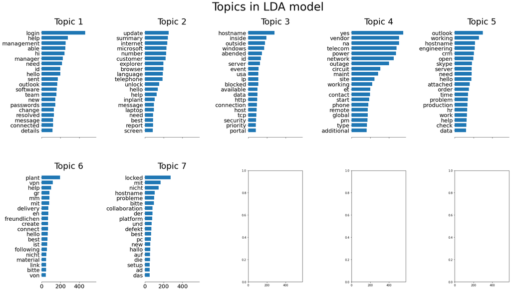

```python
tf_feature_names = vectorizer.get_feature_names()

def plot_top_words(model, feature_names, n_top_words, title):
    fig, axes = plt.subplots(2, 5, figsize=(30, 15), sharex=True)
    axes = axes.flatten()
    for topic_idx, topic in enumerate(model.components_):
        top_features_ind = topic.argsort()[:-n_top_words - 1:-1]
        top_features = [feature_names[i] for i in top_features_ind]
        print(top_features)
        weights = topic[top_features_ind]

        ax = axes[topic_idx]
        ax.barh(top_features, weights, height=0.7)
        ax.set_title(f'Topic {topic_idx +1}',
                     fontdict={'fontsize': 30})
        ax.invert_yaxis()
        ax.tick_params(axis='both', which='major', labelsize=20)
        for i in 'top right left'.split():
            ax.spines[i].set_visible(False)
        fig.suptitle(title, fontsize=40)

    plt.subplots_adjust(top=0.90, bottom=0.05, wspace=0.90, hspace=0.3)
    plt.show()

plot_top_words(LDA, tf_feature_names, 20, 'Topics in LDA model')
```

#### Word2Vec

Word2vec is a deep learning method for creating vector representations of words. There are basically two word2vec approaches: continuous skip-gram modeling (SG) or continuous bag of words (CBOW). Both create word vector representations, but with different approaches. The basic idea for skip-gram modeling, is given a word wi , predict the context wi−2 , wi−1 , wi+1 , wi+2 of this word. Whereas for the continuous bag of words approach, this process is reversed; given the context wi−2 , wi−1 , wi+1 , wi+2 , predict word wi .

```python
df1= dfTicketngrams[['LemmaString','Assignment group']]
df1.head()
```

|  | LemmaString | Assignment group |
| --- | --- | --- |
| 0 | login verified details employee manager chec... | GRP_0 |
| 1 | outlook hmjdrvpb komuaywn hello team meeting... | GRP_0 |
| 2 | log vpn eylqgodm ybqkwiam hi best | GRP_0 |
| 3 | hr page | GRP_0 |
| 4 | skype | GRP_0 |

```python
y=df1["Assignment group"]
```

```python
X_train, X_test, y_train, y_test = train_test_split(df1, y, test_size=0.2)
```

```python
sentences = []
for sentence_group in X_train.LemmaString:
    sentences.extend(sentence_group)

print("Number of sentences: {}.".format(len(sentences)))
print("Number of texts: {}.".format(len(X_train)))
```

```
Number of sentences: 644080.
Number of texts: 6800.
```

```python
import multiprocessing

from gensim.models import Word2Vec
```

```python
%%time
# Set values for various parameters
num_features = 100    # Word vector dimensionality
min_word_count = 1    # Minimum word count
num_workers = 4       # Number of threads to run in parallel
context = 6           # Context window size
downsampling = 1e-3   # Downsample setting for frequent words

# Initialize and train the model
W2Vmodel = Word2Vec(sentences=sentences,
                    sg=1,
                    hs=0,
                    workers=num_workers,
                    size=num_features,
                    min_count=min_word_count,
                    window=context,
                    sample=downsampling,
                    negative=5,
                    iter=30)
```

```
CPU times: user 17.2 s, sys: 195 ms, total: 17.4 s
Wall time: 17.2 s
```

```python
def get_w2v_features(w2v_model, sentence_group):
    """ Transform a sentence_group (containing multiple lists
    of words) into a feature vector. It averages out all the
    word vectors of the sentence_group.
    """
    words = sentence_group  # words in text
    index2word_set = set(w2v_model.wv.vocab.keys())  # words known to model

    featureVec = np.zeros(w2v_model.vector_size, dtype="float32")

    # Initialize a counter for number of words in a review
    nwords = 0
    # Loop over each word in the comment and, if it is in the model's vocabulary, add its feature vector to the total
    for word in words:
        if word in index2word_set:
            featureVec = np.add(featureVec, w2v_model[word])
            nwords += 1.

    # Divide the result by the number of words to get the average
    if nwords > 0:
        featureVec = np.divide(featureVec, nwords)
    return featureVec

X_train['w2v_features'] = list(map(lambda sen_group:
                                      get_w2v_features(W2Vmodel, sen_group),
                                      X_train.LemmaString))
```

```python
X_train.head()
```

|  | LemmaString | Assignment group | w2v_features |
| --- | --- | --- | --- |
| 2706 | remote connection open oss hrp enter d havin... | GRP_2 | [-0.00018352355, 0.0009023524, -0.0010922021, ... |
| 6263 | circuit outage india telecom vendor mbps cir... | GRP_8 | [-8.11499e-05, 0.00092685124, -0.0010605876, 0... |
| 4687 | unlock | GRP_0 | [-0.00052690477, 0.00065040344, -0.0012082632,... |
| 3966 | switzerlandim blocked netweaver vogtfyne isu... | GRP_0 | [-9.0697096e-05, 0.00051244756, -0.00096197403... |
| 5441 | ooo till friday crm web load page | GRP_0 | [-0.0007578775, 0.0010019481, -0.0015501071, 0... |

```python
X_train.info()
```

```
<class 'pandas.core.frame.DataFrame'>
Int64Index: 6800 entries, 2706 to 7270
Data columns (total 3 columns):
 #   Column            Non-Null Count  Dtype
---  ------            --------------  -----
 0   LemmaString       6800 non-null   object
 1   Assignment group  6800 non-null   object
 2   w2v_features      6800 non-null   object
dtypes: object(3)
memory usage: 212.5+ KB
```

```python
from sklearn.preprocessing import LabelEncoder

label_encoder = LabelEncoder()

label_encoder.fit(X_train["Assignment group"])
X_train['group_id'] = label_encoder.transform(X_train["Assignment group"])
```

```python
from sklearn.preprocessing import LabelEncoder

label_encoder = LabelEncoder()

label_encoder.fit(X_test["Assignment group"])
X_test['group_id'] = label_encoder.transform(X_test["Assignment group"])
```

```python
def get_cross_validated_model(model, param_grid, X, y, nr_folds=5):
    """ Trains a model by doing a grid search combined with cross validation.
    args:
        model: your model
        param_grid: dict of parameter values for the grid search
    returns:
        Model trained on entire dataset with hyperparameters chosen from best results in the grid search.
    """
    # train the model (since the evaluation is based on the logloss, we'll use neg_log_loss here)
    grid_cv = GridSearchCV(model, param_grid=param_grid, scoring='neg_log_loss', cv=nr_folds, n_jobs=-1, verbose=True, return_train_score=True)
    best_model = grid_cv.fit(X, y)
    # show top models with parameter values
    result_df = pd.DataFrame(best_model.cv_results_)
    #show_columns = ['mean_test_score', 'mean_train_score', 'rank_test_score']
    show_columns = ['mean_test_score', 'rank_test_score']
    for col in result_df.columns:
        if col.startswith('param_'):
            show_columns.append(col)
    display(result_df[show_columns].sort_values(by='rank_test_score').head())
    return best_model
```

```python
from gensim.models.ldamulticore import LdaMulticore
```

```python
%%time
num_topics = 10
#A multicore approach to decrease training time
lda_model = gensim.models.LdaMulticore(corpus=corpus,
                                       id2word=id2word,
                                       num_topics=num_topics)
```

```
CPU times: user 4.96 s, sys: 174 ms, total: 5.13 s
Wall time: 5.28 s
```

```python
corpus_train = corpus[:6800]
```

```python
corpus_test = corpus[:1700]
```

```python
def document_to_lda_features(lda_model, document):
    """ Transforms a bag of words document to features.
    It returns the proportion of how much each topic was
    present in the document.
    """
    topic_importances = lda_model.get_document_topics(document, minimum_probability=0)
    topic_importances = np.array(topic_importances)
    return topic_importances[:,1]

X_train['lda_features'] = list(map(lambda doc:
                                      document_to_lda_features(lda_model, doc),
                                      corpus_train))
```

```python
X_train.head()
```

|  | LemmaString | Assignment group | w2v_features | group_id | lda_features |
| --- | --- | --- | --- | --- | --- |
| 2706 | remote connection open oss hrp enter d havin... | GRP_2 | [-0.00018352355, 0.0009023524, -0.0010922021, ... | 9 | [0.9181772470474243, 0.00909374188631773, 0.00... |
| 6263 | circuit outage india telecom vendor mbps cir... | GRP_8 | [-8.11499e-05, 0.00092685124, -0.0010605876, 0... | 22 | [0.006670041941106319, 0.006667520385235548, 0... |
| 4687 | unlock | GRP_0 | [-0.00052690477, 0.00065040344, -0.0012082632,... | 0 | [0.014287836849689484, 0.014288479462265968, 0... |
| 3966 | switzerlandim blocked netweaver vogtfyne isu... | GRP_0 | [-9.0697096e-05, 0.00051244756, -0.00096197403... | 0 | [0.03334061801433563, 0.033339548856019974, 0.... |
| 5441 | ooo till friday crm web load page | GRP_0 | [-0.0007578775, 0.0010019481, -0.0015501071, 0... | 0 | [0.050015825778245926, 0.05000128224492073, 0.... |

```python
# since train_data['lda_features'] and train_data['w2v_features'] don't have the needed shape and type yet,
# we first have to transform every entry
X_train_lda = np.array(list(map(np.array, X_train.lda_features)))
X_train_w2v = np.array(list(map(np.array, X_train.w2v_features)))
X_train_combined = np.append(X_train_lda, X_train_w2v, axis=1)
```

```python
from sklearn.utils.testing import all_estimators

estimators = all_estimators()

#for name, class in estimators: if hasattr(class, 'predict_proba'): print(name)
```

```python
# store all models in a dictionary
models = dict()
```

```python
models
```

[output not shown]

### We use a Logistic Regression model as its a classifcation problem

```python
# LDA features only
lr = LogisticRegression()

param_grid = {'penalty': ['l1', 'l2']}

best_lr_lda = get_cross_validated_model(lr, param_grid, X_train_lda, X_train.group_id)

models['best_lr_lda'] = best_lr_lda
```

```
Fitting 5 folds for each of 2 candidates, totalling 10 fits
```

```
[Parallel(n_jobs=-1)]: Using backend LokyBackend with 2 concurrent workers.
[Parallel(n_jobs=-1)]: Done  10 out of  10 | elapsed:    3.9s finished
```

|  | mean_test_score | rank_test_score | param_penalty |
| --- | --- | --- | --- |
| 1 | -2.216442 | 1 | l2 |
| 0 | NaN | 2 | l1 |

```python
# Word2Vec features only
lr = LogisticRegression()

param_grid = {'penalty': ['l1', 'l2']}

best_lr_w2v = get_cross_validated_model(lr, param_grid, X_train_w2v, X_train.group_id)

models['best_lr_w2v'] = best_lr_w2v
```

```
Fitting 5 folds for each of 2 candidates, totalling 10 fits
```

```
[Parallel(n_jobs=-1)]: Using backend LokyBackend with 2 concurrent workers.
[Parallel(n_jobs=-1)]: Done  10 out of  10 | elapsed:    1.9s finished
```

|  | mean_test_score | rank_test_score | param_penalty |
| --- | --- | --- | --- |
| 1 | -2.199317 | 1 | l2 |
| 0 | NaN | 2 | l1 |

#### We can observe that model with word2vec gives us better performance as compared to model with only lda features

```python
# LDA and Word2Vec combined
lr = LogisticRegression()

param_grid = {'penalty': ['l1', 'l2']}

best_lr_combined = get_cross_validated_model(lr, param_grid, X_train_combined, X_train.group_id)

models['best_lr_combined'] = best_lr_combined
```

```
Fitting 5 folds for each of 2 candidates, totalling 10 fits
```

```
[Parallel(n_jobs=-1)]: Using backend LokyBackend with 2 concurrent workers.
[Parallel(n_jobs=-1)]: Done  10 out of  10 | elapsed:    3.9s finished
```

|  | mean_test_score | rank_test_score | param_penalty |
| --- | --- | --- | --- |
| 1 | -2.213027 | 1 | l2 |
| 0 | NaN | 2 | l1 |

A model that uses L1 regularization technique is called Lasso Regression and model which uses L2 is called Ridge Regression.The key difference between these techniques is that Lasso shrinks the less important feature’s coefficient to zero thus, removing some feature altogether. So, this works well for feature selection in case we have a huge number of features. In our case L2 works best as it minimises the least important features

```python
X_train.head()
```

|  | LemmaString | Assignment group | w2v_features | group_id | lda_features |
| --- | --- | --- | --- | --- | --- |
| 4677 | active directory locked | GRP_0 | [-0.0009748081, -0.0010611995, -0.00070943846,... | 0 | [0.009091517888009548, 0.009091184474527836, 0... |
| 2443 | request microsoft online services tyhufrey t... | GRP_0 | [-0.00060666865, -0.0006071736, -9.091753e-05,... | 0 | [0.006668400019407272, 0.006668983493000269, 0... |
| 1144 | passwords wvdxnkhf jirecvta management | GRP_17 | [-0.00062401785, -1.4240329e-06, -0.0009770694... | 6 | [0.014291989617049694, 0.014290103688836098, 0... |
| 1516 | circuit outage na usa usa anira rtr est site... | GRP_8 | [-0.00074505375, -0.0007713834, -0.00027730654... | 22 | [0.6999604105949402, 0.03333672508597374, 0.03... |
| 484 | reach management manager change mitgckqf lan... | GRP_0 | [-0.00026375515, -0.0009818455, -0.0007430129,... | 0 | [0.050010308623313904, 0.050000883638858795, 0... |

```python
# calculate the fpr and tpr for all thresholds of the classification
probs = best_lr_combined.predict_proba(X_train_combined) # we select the best_lr_combined model to calculate roc-auc curve
preds = probs[:,1]
fpr, tpr, threshold = metrics.roc_curve(X_train.group_id, preds, pos_label=1)
roc_auc = metrics.auc(fpr, tpr)
```

#### **AUC–ROC curve**

AUC–ROC curve is the model selection metric for bi–multi class classification problem. ROC is a probability curve for different classes. ROC tells us how good the model is for distinguishing the given classes, in terms of the predicted probability.

A typical ROC curve has False Positive Rate (FPR) on the X-axis and True Positive Rate (TPR) on the Y-axis.

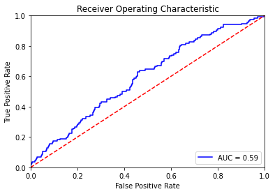

```python
plt.title('Receiver Operating Characteristic')
plt.plot(fpr, tpr, 'b', label = 'AUC = %0.2f' % roc_auc)
plt.legend(loc = 'lower right')
plt.plot([0, 1], [0, 1],'r--')
plt.xlim([0, 1])
plt.ylim([0, 1])
plt.ylabel('True Positive Rate')
plt.xlabel('False Positive Rate')
plt.show()
```

As we can see in the above output, the whole document is classfied into 7 topics and displayed the high weighted words for each topic.  
The AUC score comes out to be 0.59 for classification using LDA and word2vec

#### **Random Forest Classifier**

```python
#Build RF Model
from sklearn.ensemble import RandomForestClassifier
rf = RandomForestClassifier(n_jobs=2,n_estimators=500,criterion="entropy",random_state=9999)
rfm=rf.fit(X_train_combined, X_train.group_id)
```

```python
param_grid = {
    'n_estimators': [200, 700],
    'max_features': ['auto', 'sqrt', 'log2']
}

#param_grid = params

best_rf_combined = get_cross_validated_model(rf, param_grid, X_train_combined, X_train.group_id)

models['best_rf_combined'] = best_rf_combined
```

```
Fitting 5 folds for each of 6 candidates, totalling 30 fits
```

```
[Parallel(n_jobs=-1)]: Using backend LokyBackend with 2 concurrent workers.
[Parallel(n_jobs=-1)]: Done  30 out of  30 | elapsed: 37.0min finished
```

|  | mean_test_score | rank_test_score | param_max_features | param_n_estimators |
| --- | --- | --- | --- | --- |
| 5 | -1.772362 | 1 | log2 | 700 |
| 1 | -1.823455 | 2 | auto | 700 |
| 3 | -1.823455 | 2 | sqrt | 700 |
| 0 | -2.090582 | 4 | auto | 200 |
| 2 | -2.090582 | 4 | sqrt | 200 |

When max_features="auto", m = p and no feature subset selection is performed in the trees, so the "random forest" is actually a bagged ensemble of ordinary regression trees.

Empirical good default values are max_features=n_features for regression problems, and max_features=sqrt(n_features) for classification tasks

```python
print(best_rf_combined.best_params_)
```

```
{'max_features': 'log2', 'n_estimators': 700}
```

[figure not shown]

```python
# View a list of the features and their importance scores
importances = rf.feature_importances_
indices = np.argsort(importances)[::-1][:15]
#features = X_train_combined.columns[:]
#features= a.drop('default',1)
#plot it
plt.figure(1)
plt.title('Feature Importances')
plt.barh(range(len(indices)), importances[indices], color='b', align='center')
plt.yticks(range(len(indices)), X_train_combined[indices])
plt.xlabel('Relative Importance')
```

```python
X_test['lda_features'] = list(map(lambda doc:
                                      document_to_lda_features(lda_model, doc),
                                      corpus_test))
```

```python
X_test['w2v_features'] = list(map(lambda sen_group:
                                      get_w2v_features(W2Vmodel, sen_group),
                                      X_test.LemmaString))
```

```python
# since test_data['lda_features'] and test_data['w2v_features'] don't have the needed shape and type yet,
# we first have to transform every entry
X_test_lda = np.array(list(map(np.array, X_test.lda_features)))
X_test_w2v = np.array(list(map(np.array, X_test.w2v_features)))
X_test_combined = np.append(X_test_lda, X_test_w2v, axis=1)
```

```python
import sklearn.metrics as metrics
from sklearn.metrics import roc_curve
from sklearn.metrics import roc_auc_score
# calculate the fpr and tpr for all thresholds of the classification
probs = best_rf_combined.predict_proba(X_test_combined) # we select the best_rf_combined model to calculate roc-auc curve
preds = probs[:,1]
fpr, tpr, threshold = metrics.roc_curve(X_test.group_id, preds, pos_label=1)
roc_auc = metrics.auc(fpr, tpr)
```

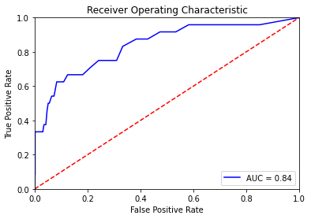

```python
import matplotlib.pyplot as plt
plt.title('Receiver Operating Characteristic')
plt.plot(fpr, tpr, 'b', label = 'AUC = %0.2f' % roc_auc)
plt.legend(loc = 'lower right')
plt.plot([0, 1], [0, 1],'r--')
plt.xlim([0, 1])
plt.ylim([0, 1])
plt.ylabel('True Positive Rate')
plt.xlabel('False Positive Rate')
plt.show()
```

We see our AUC value has improved quite a lot for RF model 0.84

```python
y_pred=rf.predict(X_test_combined)
```

```python
#calculate Confusion Matrix
from sklearn.metrics import confusion_matrix
from sklearn.metrics import accuracy_score
def calculate_confusion_matrix(y_true, y_pred):

    cm=confusion_matrix(y_true, y_pred)
    print(cm)
```

```python
calculate_confusion_matrix(X_test.group_id, y_pred)
print(accuracy_score(X_test.group_id, y_pred))
```

```
[[741   1   0   0   0   0   0   0   0   0   1   0   0   0   0   3   0   1
    0   0   0   0   8   3   3]
 [ 15   8   0   0   0   0   0   0   0   0   0   0   0   0   0   0   0   0
    0   0   0   0   1   0   0]
 [ 33   0   7   0   0   0   0   0   0   0   0   0   0   0   0   0   0   0
    0   0   0   0   0   1   1]
 [ 25   0   0   0   0   0   0   0   0   0   0   0   0   0   0   0   0   0
    0   0   0   0   1   0   0]
 [ 16   0   1   0   1   0   0   0   0   0   0   0   0   0   0   0   0   0
    0   0   0   0   1   0   1]
 [ 18   0   0   0   0   0   0   0   0   0   0   0   0   0   0   0   0   0
    0   0   0   0   0   0   2]
 [  6   0   0   0   0   0  11   0   0   0   0   0   0   0   0   0   0   0
    0   0   0   0   0   0   0]
 [ 17   0   0   0   0   0   0   0   0   0   0   0   0   0   0   0   0   0
    0   0   0   0   0   0   1]
 [ 57   0   1   0   0   0   0   0   0   0   0   0   0   0   0   0   0   0
    0   0   0   0   0   0   0]
 [ 40   0   0   0   0   0   0   0   0   8   0   0   0   0   1   0   0   0
    0   0   0   0   0   0   2]
 [ 51   0   0   0   0   0   0   0   0   0  21   0   0   0   0   0   0   0
    0   0   0   0   0   0   0]
 [ 20   0   0   0   0   0   0   0   0   0   0   0   0   0   0   0   0   0
    0   0   0   0   0   0   0]
 [ 13   0   0   0   0   0   0   0   0   0   0   0   0   0   0   0   0   0
    0   0   0   0   0   0   0]
 [ 20   0   0   0   0   0   0   0   0   0   0   0   0   0   0   0   0   0
    0   0   0   0   0   0   0]
 [ 41   0   0   0   0   0   0   0   0   0   0   0   0   0   1   0   0   0
    0   0   0   0   0   0   0]
 [ 21   0   0   0   0   0   0   0   0   1   0   0   0   0   0   1   0   0
    0   0   0   0   1   0   0]
 [ 14   0   0   0   0   0   0   0   0   0   0   0   0   0   0   0   0   0
    0   0   0   0   0   0   0]
 [ 12   0   0   0   0   0   0   0   0   0   0   0   0   0   0   0   0   0
    0   0   0   0   0   0   0]
 [ 22   0   0   0   0   0   0   0   0   0   0   0   0   0   0   0   0   0
    2   0   0   0   1   0   1]
 [  6   0   0   0   0   0   0   0   0   0   0   0   0   0   0   0   0   0
    0  13   0   0   9   0   0]
 [ 16   1   0   0   0   0   0   0   0   0   0   0   0   0   0   0   0   0
    0   0  11   0  10   7   1]
 [ 18   0   0   0   0   0   0   0   0   0   0   0   0   0   0   0   0   0
    0   0   0   0   0   0   0]
 [ 34   2   0   0   0   0   0   0   0   0   0   0   0   0   0   0   0   0
    1   2   4   0  65  10   3]
 [ 24   1   1   0   0   0   0   0   0   0   0   0   0   0   0   0   0   0
    0   0   4   0  15  11   0]
 [120   0   2   0   0   0   0   0   0   1   0   0   0   0   1   1   0   0
    0   2   0   0   9   2  13]]
0.5376470588235294
```

Our accuracy score is 54% , but this can be improved when worked on a balanced dataset

# Model Building

### Approach - 1 Machine Learning approach

Train and Test Split

```python
df2= df1Ticketngrams[['LemmaString','Assignment group']]
df2.head()
```

|  | LemmaString | Assignment group |
| --- | --- | --- |
| 0 | login verified details employee manager chec... | GRP_0 |
| 1 | outlook hmjdrvpb komuaywn hello team meeting... | GRP_0 |
| 2 | log vpn eylqgodm ybqkwiam hi best | GRP_0 |
| 3 | hr page | GRP_0 |
| 4 | skype | GRP_0 |

```python
X_train = df2.loc[:6000, 'LemmaString'].values
y_train = df2.loc[:6000, 'Assignment group'].values
X_test = df2.loc[6001:, 'LemmaString'].values
y_test = df2.loc[6001:, 'Assignment group'].values
```

```python
vectorizer = TfidfVectorizer()
train_vectors = vectorizer.fit_transform(X_train)
test_vectors = vectorizer.transform(X_test)
print(train_vectors.shape, test_vectors.shape)
```

```
(6001, 11675) (2499, 11675)
```

#### **Naive Bayes**

```python
clf = MultinomialNB().fit(train_vectors, y_train)
```

```python
predicted = clf.predict(test_vectors)
print(accuracy_score(y_test,predicted))
```

```
0.5042016806722689
```

Accuracy score for Naive Bayes comes out to be 0.504

```python
print(predicted[1])
```

```
GRP_0
```

```python
cm = confusion_matrix(y_test, predicted)
cm
```

```
array([[1131,    0,    0,    0,    0,    0,    0,    0,    0,    0,    0,
           0,    0,    0,    0,    0,    0,    0,    0,    0,    0,    0,
           3,    0,    0],
       [  23,    3,    0,    0,    0,    0,    0,    0,    0,    0,    0,
           0,    0,    0,    0,    0,    0,    0,    0,    0,    0,    0,
           0,    0,    0],
       [  88,    0,    1,    0,    0,    0,    0,    0,    0,    0,    0,
           0,    0,    0,    0,    0,    0,    0,    0,    0,    0,    0,
           2,    0,    3],
       [  41,    0,    0,    0,    0,    0,    0,    0,    0,    0,    0,
           0,    0,    0,    0,    0,    0,    0,    0,    0,    0,    0,
           0,    0,    0],
       [  38,    0,    0,    0,    0,    0,    0,    0,    0,    0,    0,
           0,    0,    0,    0,    0,    0,    0,    0,    0,    0,    0,
           0,    0,    0],
       [  18,    0,    0,    0,    0,    0,    0,    0,    0,    0,    0,
           0,    0,    0,    0,    0,    0,    0,    0,    0,    0,    0,
           0,    0,    0],
       [  19,    0,    0,    0,    0,    0,    0,    0,    0,    0,    0,
           0,    0,    0,    0,    0,    0,    0,    0,    0,    0,    0,
           0,    0,    0],
       [  25,    0,    0,    0,    0,    0,    0,    0,    0,    0,    0,
           0,    0,    0,    0,    0,    0,    0,    0,    0,    0,    0,
           0,    0,    0],
       [  68,    0,    0,    0,    0,    0,    0,    0,    0,    0,    0,
           0,    0,    0,    0,    0,    0,    0,    0,    0,    0,    0,
           0,    0,    0],
       [  63,    0,    0,    0,    0,    0,    0,    0,    0,    1,    0,
           0,    0,    0,    0,    0,    0,    0,    0,    0,    0,    0,
           0,    0,    0],
       [  64,    0,    0,    0,    0,    0,    0,    0,    0,    0,   20,
           0,    0,    0,    0,    0,    0,    0,    0,    0,    0,    0,
           0,    0,    0],
       [  24,    0,    0,    0,    0,    0,    0,    0,    0,    0,    0,
           0,    0,    0,    0,    0,    0,    0,    0,    0,    0,    0,
           0,    0,    0],
       [  10,    0,    0,    0,    0,    0,    0,    0,    0,    0,    0,
           0,    0,    0,    0,    0,    0,    0,    0,    0,    0,    0,
           0,    0,    0],
       [  30,    0,    0,    0,    0,    0,    0,    0,    0,    0,    0,
```

[output cut: 20 more lines]

```
       [  67,    0,    0,    0,    0,    0,    0,    0,    0,    0,    0,
           0,    0,    0,    0,    0,    0,    0,    0,    0,    0,    0,
           8,    0,    0],
       [  21,    0,    0,    0,    0,    0,    0,    0,    0,    0,    0,
           0,    0,    0,    0,    0,    0,    0,    0,    0,    0,    0,
           0,    0,    0],
       [  97,    0,    1,    0,    0,    0,    0,    0,    0,    0,    0,
           0,    0,    0,    0,    0,    0,    0,    0,    0,    0,    0,
          96,    0,    1],
       [  71,    0,    0,    0,    0,    0,    0,    0,    0,    0,    0,
           0,    0,    0,    0,    0,    0,    0,    0,    0,    0,    0,
           0,    0,    0],
       [ 253,    0,    1,    0,    0,    0,    0,    0,    0,    2,    0,
           0,    0,    0,    0,    0,    0,    0,    0,    0,    0,    0,
           8,    0,    8]])
```

##### **SVM Model**

```python
SVM = svm.SVC(C=1.0, kernel='linear', gamma='auto')
```

```python
SVM.fit(train_vectors ,y_train)
```

```
SVC(C=1.0, break_ties=False, cache_size=200, class_weight=None, coef0=0.0,
    decision_function_shape='ovr', degree=3, gamma='auto', kernel='linear',
    max_iter=-1, probability=False, random_state=None, shrinking=True,
    tol=0.001, verbose=False)
```

```python
predictions = SVM.predict(test_vectors)
print("SVM Accuracy Score -> ",accuracy_score(predictions, y_test)*100)
```

```
SVM Accuracy Score ->  61.58463385354141
```

```python
Lcm = confusion_matrix(y_test, predictions)
print(Lcm)
```

```
[[1084    0   10    2    0    0    3    0    6    0    2    2    0    1
     2    0    0    1    0    0    0    9    0    0   12]
 [  16    4    0    1    0    0    0    0    0    0    0    0    0    0
     0    0    0    0    0    0    0    0    0    0    5]
 [  29    0   45    0    4    0    0    0    0    4    1    1    0    0
     1    0    0    0    0    0    0    0    4    0    5]
 [  20    0    0   15    0    0    0    1    0    0    0    0    0    0
     0    0    0    0    0    0    0    0    0    0    5]
 [  13    0    4    0   13    0    0    0    0    0    0    0    0    0
     0    0    0    0    0    0    0    0    1    0    7]
 [  16    0    0    0    0    0    0    0    0    0    0    0    0    0
     0    0    0    0    0    0    0    0    0    0    2]
 [   0    0    0    0    0    0   19    0    0    0    0    0    0    0
     0    0    0    0    0    0    0    0    0    0    0]
 [   7    1    0    4    0    0    0    8    0    0    0    0    0    0
     0    0    0    0    0    0    0    0    0    0    5]
 [  52    0    1    0    0    0    0    0    7    1    0    0    0    0
     5    0    0    0    0    0    0    0    1    0    1]
 [  34    0    2    0    0    0    0    0    0   19    0    0    0    0
     1    0    0    0    0    0    0    0    0    0    8]
 [  10    0    0    0    0    0    0    0    0    0   72    0    0    0
     1    0    0    0    0    0    0    0    0    0    1]
 [  16    0    0    0    0    0    0    0    0    0    0    5    0    0
     0    0    0    0    0    0    0    0    0    0    3]
 [   8    0    0    0    0    0    0    0    0    0    0    0    0    0
     0    0    0    0    0    0    0    0    0    0    2]
 [  14    2    0    2    0    0    0    0    0    0    0    0    0    7
     0    0    0    0    0    0    0    0    1    0    5]
 [  45    0    0    0    0    0    0    0    1    0    0    0    0    0
     6    0    0    0    0    0    0    1    0    0    3]
 [  15    0    0    0    0    0    0    0    1    0    0    0    0    0
     0    0    0    0    0    0    0    1    0    0    1]
 [  20    0    0    0    0    0    0    0    1    1    4    0    0    0
     0    0    7    0    0    0    0    1    0    0    1]
 [  13    0    1    0    0    0    0    0    0    0    0    1    0    0
     0    0    0    2    0    0    0    0    0    0    0]
 [  22    0    0    0    0    0    0    0    0    0    0    1    0    0
     0    0    0    0    3    0    0    0   10    0    1]
 [   6    0    1    0    0    0    0    0    0    0    0    0    0    0
     0    0    0    0    0   14    0    0    5    0    0]
 [  50    0    0    1    0    0    0    1    0    0    0    0    0    0
     0    0    0    0    0    0   20    0    1    0    2]
 [   5    0    0    0    0    0    0    0    0    0    0    0    0    0
     0    0    0    0    0    0    0   16    0    0    0]
 [  75    0    6    0    1    0    0    0    0    0    0    0    0    0
     0    0    0    0    0   10    0    0  102    0    1]
 [  62    0    1    1    0    0    0    0    0    0    0    0    0    0
     0    0    0    0    0    0    0    0    1    5    1]
 [ 165    1    9    3    1    0    0    1    0    2    2    0    0    0
     1    0    1    0    0    5    0    3   12    0   66]]
```

```python
print(classification_report(y_test, predictions))
```

```
              precision    recall  f1-score   support

       GRP_0       0.60      0.96      0.74      1134
      GRP_10       0.50      0.15      0.24        26
      GRP_12       0.56      0.48      0.52        94
      GRP_13       0.52      0.37      0.43        41
      GRP_14       0.68      0.34      0.46        38
      GRP_16       0.00      0.00      0.00        18
      GRP_17       0.86      1.00      0.93        19
      GRP_18       0.73      0.32      0.44        25
      GRP_19       0.44      0.10      0.17        68
       GRP_2       0.70      0.30      0.42        64
      GRP_24       0.89      0.86      0.87        84
      GRP_25       0.50      0.21      0.29        24
      GRP_26       0.00      0.00      0.00        10
      GRP_29       0.88      0.23      0.36        31
       GRP_3       0.35      0.11      0.16        56
      GRP_31       0.00      0.00      0.00        18
      GRP_33       0.88      0.20      0.33        35
      GRP_34       0.67      0.12      0.20        17
       GRP_4       1.00      0.08      0.15        37
       GRP_5       0.48      0.54      0.51        26
       GRP_6       1.00      0.27      0.42        75
       GRP_7       0.52      0.76      0.62        21
       GRP_8       0.74      0.52      0.61       195
       GRP_9       1.00      0.07      0.13        71
       GRP_A       0.48      0.24      0.32       272

    accuracy                           0.62      2499
   macro avg       0.60      0.33      0.37      2499
weighted avg       0.63      0.62      0.56      2499
```

##### **Grid Search CV**

```python
params_grid = [{'kernel': ['linear','rbf'], 'C': [10.0,1.0,0.1,0.01]}]

svm_model_pc = GridSearchCV(svm.SVC(probability=True, decision_function_shape='ovr'), params_grid,cv=5,  verbose=1)

svm_model_pc.fit(train_vectors, y_train)

svm_model_pc.score

# View the accuracy score
print('Best score for training data:', svm_model_pc.best_score_,"\n")

# View the best parameters for the model found using grid search
print('Best C:',svm_model_pc.best_estimator_.C,"\n")
print('Best Kernel:',svm_model_pc.best_estimator_.kernel,"\n")

final_model_pc = svm_model_pc.best_estimator_

y_pred = final_model_pc.predict(test_vectors)
```

```
Fitting 5 folds for each of 8 candidates, totalling 40 fits
```

```
[Parallel(n_jobs=1)]: Using backend SequentialBackend with 1 concurrent workers.
[Parallel(n_jobs=1)]: Done  40 out of  40 | elapsed: 19.6min finished
```

```
Best score for training data: 0.6173967527060782

Best C: 1.0

Best Kernel: linear
```

```python
print("Training score for GridSearch SVM: %f" % final_model_pc.score(train_vectors, y_train))
print("Testing score for GridSearch SVM: %f" % final_model_pc.score(test_vectors, y_test))
print("\n")
```

```
Training score for GridSearch SVM: 0.797200
Testing score for GridSearch SVM: 0.615846
```

```python
Lcm = confusion_matrix(y_test, y_pred)
print(Lcm)
```

```
[[1084    0   10    2    0    0    3    0    6    0    2    2    0    1
     2    0    0    1    0    0    0    9    0    0   12]
 [  16    4    0    1    0    0    0    0    0    0    0    0    0    0
     0    0    0    0    0    0    0    0    0    0    5]
 [  29    0   45    0    4    0    0    0    0    4    1    1    0    0
     1    0    0    0    0    0    0    0    4    0    5]
 [  20    0    0   15    0    0    0    1    0    0    0    0    0    0
     0    0    0    0    0    0    0    0    0    0    5]
 [  13    0    4    0   13    0    0    0    0    0    0    0    0    0
     0    0    0    0    0    0    0    0    1    0    7]
 [  16    0    0    0    0    0    0    0    0    0    0    0    0    0
     0    0    0    0    0    0    0    0    0    0    2]
 [   0    0    0    0    0    0   19    0    0    0    0    0    0    0
     0    0    0    0    0    0    0    0    0    0    0]
 [   7    1    0    4    0    0    0    8    0    0    0    0    0    0
     0    0    0    0    0    0    0    0    0    0    5]
 [  52    0    1    0    0    0    0    0    7    1    0    0    0    0
     5    0    0    0    0    0    0    0    1    0    1]
 [  34    0    2    0    0    0    0    0    0   19    0    0    0    0
     1    0    0    0    0    0    0    0    0    0    8]
 [  10    0    0    0    0    0    0    0    0    0   72    0    0    0
     1    0    0    0    0    0    0    0    0    0    1]
 [  16    0    0    0    0    0    0    0    0    0    0    5    0    0
     0    0    0    0    0    0    0    0    0    0    3]
 [   8    0    0    0    0    0    0    0    0    0    0    0    0    0
     0    0    0    0    0    0    0    0    0    0    2]
 [  14    2    0    2    0    0    0    0    0    0    0    0    0    7
     0    0    0    0    0    0    0    0    1    0    5]
 [  45    0    0    0    0    0    0    0    1    0    0    0    0    0
     6    0    0    0    0    0    0    1    0    0    3]
 [  15    0    0    0    0    0    0    0    1    0    0    0    0    0
     0    0    0    0    0    0    0    1    0    0    1]
 [  20    0    0    0    0    0    0    0    1    1    4    0    0    0
     0    0    7    0    0    0    0    1    0    0    1]
 [  13    0    1    0    0    0    0    0    0    0    0    1    0    0
     0    0    0    2    0    0    0    0    0    0    0]
 [  22    0    0    0    0    0    0    0    0    0    0    1    0    0
     0    0    0    0    3    0    0    0   10    0    1]
 [   6    0    1    0    0    0    0    0    0    0    0    0    0    0
     0    0    0    0    0   14    0    0    5    0    0]
 [  50    0    0    1    0    0    0    1    0    0    0    0    0    0
     0    0    0    0    0    0   20    0    1    0    2]
 [   5    0    0    0    0    0    0    0    0    0    0    0    0    0
     0    0    0    0    0    0    0   16    0    0    0]
 [  75    0    6    0    1    0    0    0    0    0    0    0    0    0
     0    0    0    0    0   10    0    0  102    0    1]
 [  62    0    1    1    0    0    0    0    0    0    0    0    0    0
     0    0    0    0    0    0    0    0    1    5    1]
 [ 165    1    9    3    1    0    0    1    0    2    2    0    0    0
     1    0    1    0    0    5    0    3   12    0   66]]
```

#### **Deep Learning Approach**

```python
df2.head()
```

|  | LemmaString | Assignment group |
| --- | --- | --- |
| 0 | login verified details employee manager chec... | GRP_0 |
| 1 | outlook hmjdrvpb komuaywn hello team meeting... | GRP_0 |
| 2 | log vpn eylqgodm ybqkwiam hi best | GRP_0 |
| 3 | hr page | GRP_0 |
| 4 | skype | GRP_0 |

```python
## TOTAL NUMBER OF WORDS USED IN EACH HEADLINE
df2['nb_words'] = df2.LemmaString.apply(lambda x: len(x.split()))

## TOTAL NUMBER OF UNIQUE WORDS USED IN EACH HEADLINE
df2['nb_unique_words'] = df2.LemmaString.apply(lambda x: len(set(x.split())))

## TOTAL NUMBER OF CHARACTERS USED IN EACH HEADLINE
df2['nb_char'] = df2.LemmaString.apply(lambda x: len(x))
```

```python
df2.LemmaString
```

```
0         login verified details employee manager chec...
1         outlook hmjdrvpb komuaywn hello team meeting...
2                       log vpn eylqgodm ybqkwiam hi best
3                                                 hr page
4                                                   skype
                              ...
8495      emails coming zz mail avglmrts vhqmtiua good...
8496                                   telephony software
8497                        vip windows tifpdchb pedxruyf
8498      machine o est funcionando utilities finish d...
8499      mehreren pc lassen sich verschiedene prgramd...
Name: LemmaString, Length: 8500, dtype: object
```

```python
maxlen = df2['nb_words'].max()
print(maxlen)
```

```
656
```

```python
max_features = 10000
embedding_size = 50
```

```python
tokenizer_obj=Tokenizer(num_words=max_features)
tokenizer_obj.fit_on_texts(corpus1)
sequences=tokenizer_obj.texts_to_sequences(corpus1)
```

```python
from sklearn import preprocessing
X = tokenizer_obj.texts_to_sequences(corpus1)
X = pad_sequences(X, maxlen = maxlen)

df2['Assignment group'].astype(str)
label_encoder = preprocessing.LabelEncoder()
# Encode labels in column 'species'.
y = df2['Assignment group']= label_encoder.fit_transform(df2['Assignment group'])
y = to_categorical(y, num_classes= 74)

print("Number of Samples:", len(X))
print("Number of Labels: ", len(y))
```

```
Number of Samples: 8500
Number of Labels:  8500
```

Get vocab size

```python
word_index = tokenizer_obj.word_index
num_words = len(word_index)+1
print(num_words)
```

```
14669
```

Word Embedding

```python
embeddings = {}
for o in open(path+'/glove.6B.50d.txt','r'):
    word = o.split(" ")[0]
    # print(word)
    embd = o.split(" ")[1:]
    embd = np.asarray(embd, dtype='float32')
    # print(embd)
    embeddings[word] = embd
```

Create a weight matrix for words in training docs

```python
embedding_matrix = np.zeros((num_words, embedding_size))

for word, i in tokenizer_obj.word_index.items():
  if i >= max_features: continue
  embedding_vector = embeddings.get(word)
  if embedding_vector is not None:
     embedding_matrix[i] = embedding_vector

len(embeddings.values())
```

```
400000
```

###### Create and Compile your Model

#### **LSTM**

```python
model = Sequential()
model.add(Embedding(num_words, embedding_size, weights = [embedding_matrix]))
model.add(Bidirectional(LSTM(128, return_sequences = True)))
model.add(GlobalMaxPool1D())
model.add(Dropout(0.2))
model.add(Dense(74, activation="softmax"))
model.compile(loss='categorical_crossentropy', optimizer='adam', metrics=['accuracy'])
```

```python
model.summary()
```

```
Model: "sequential_5"
_________________________________________________________________
Layer (type)                 Output Shape              Param #
=================================================================
embedding_12 (Embedding)     (None, None, 50)          733450
_________________________________________________________________
bidirectional_5 (Bidirection (None, None, 256)         183296
_________________________________________________________________
global_max_pooling1d_5 (Glob (None, 256)               0
_________________________________________________________________
dropout_12 (Dropout)         (None, 256)               0
_________________________________________________________________
dense_12 (Dense)             (None, 74)                19018
=================================================================
Total params: 935,764
Trainable params: 935,764
Non-trainable params: 0
_________________________________________________________________
```

Fit your model

```python
from keras.callbacks import EarlyStopping
history = model.fit(X,y,batch_size=100,epochs=50,validation_split=0.2,callbacks=[EarlyStopping(monitor='val_loss',min_delta=0.0001)])
```

Plot Graph

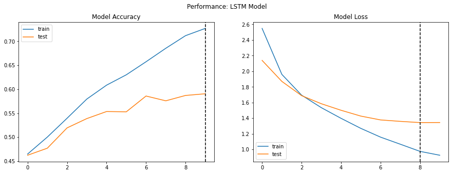

```python
import matplotlib.pyplot as plt
fig, (ax1, ax2) = plt.subplots(1,2,figsize=(15,5))
fig.suptitle("Performance: LSTM Model")
ax1.plot(history.history['accuracy'])
ax1.plot(history.history['val_accuracy'])
cut = np.where(history.history['val_accuracy'] == np.max(history.history['val_accuracy']))[0][0]
ax1.axvline(x=cut, color='k', linestyle='--')
ax1.set_title("Model Accuracy")
ax1.legend(['train', 'test'])

ax2.plot(history.history['loss'])
ax2.plot(history.history['val_loss'])
cut = np.where(history.history['val_loss'] == np.min(history.history['val_loss']))[0][0]
ax2.axvline(x=cut, color='k', linestyle='--')
ax2.set_title("Model Loss")
ax2.legend(['train', 'test'])
plt.show()
```

#### **GRU Model**

```python
model = Sequential()
model.add(Embedding(num_words, embedding_size, weights = [embedding_matrix]))
model.add(Bidirectional(GRU(128, return_sequences = True)))
model.add(GlobalMaxPool1D())
model.add(Dropout(0.2))
model.add(Dense(74, activation="softmax"))
model.compile(loss='categorical_crossentropy', optimizer='adam', metrics=['accuracy'])
```

```python
model.summary()
```

```
Model: "sequential_6"
_________________________________________________________________
Layer (type)                 Output Shape              Param #
=================================================================
embedding_13 (Embedding)     (None, None, 50)          733450
_________________________________________________________________
bidirectional_6 (Bidirection (None, None, 256)         138240
_________________________________________________________________
global_max_pooling1d_6 (Glob (None, 256)               0
_________________________________________________________________
dropout_13 (Dropout)         (None, 256)               0
_________________________________________________________________
dense_13 (Dense)             (None, 74)                19018
=================================================================
Total params: 890,708
Trainable params: 890,708
Non-trainable params: 0
_________________________________________________________________
```

Fit your model

```python
from keras.callbacks import EarlyStopping
history = model.fit(X,y,batch_size=100,epochs=50,validation_split=0.2,callbacks=[EarlyStopping(monitor='val_loss',min_delta=0.0001)])
```

Plot Graph

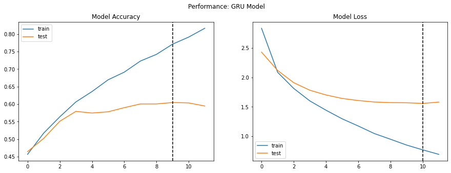

```python
fig, (ax1, ax2) = plt.subplots(1,2,figsize=(15,5))
fig.suptitle("Performance: GRU Model")
ax1.plot(history.history['accuracy'])
ax1.plot(history.history['val_accuracy'])
cut = np.where(history.history['val_accuracy'] == np.max(history.history['val_accuracy']))[0][0]
ax1.axvline(x=cut, color='k', linestyle='--')
ax1.set_title("Model Accuracy")
ax1.legend(['train', 'test'])

ax2.plot(history.history['loss'])
ax2.plot(history.history['val_loss'])
cut = np.where(history.history['val_loss'] == np.min(history.history['val_loss']))[0][0]
ax2.axvline(x=cut, color='k', linestyle='--')
ax2.set_title("Model Loss")
ax2.legend(['train', 'test'])
plt.show()
```

## Summary of Model Building:

Currently, we have used Classical Machine Learning Model such as Naive Bayes, SVM, GridSearchCV on SVM model,and Deep Learning Models LSTM and GRU models for said text classification.  
As can be seen, the accuracy along with precision and recall for different classes is very low.  
The reason for this low accuracy is mentioned below:

```
     Highly Imbalanced Dataset
     Proper Hyperparameter tuning may be required
     Proper Model selection may be required
```

We may try below steps to fine tune our model next.

```
  1. Fine tuning existing model with hyper parameters.
  2. Handling imbalance of classes if accuracy with step 1 is not achieved.
  3. Using a different approach altogether. Since the base of the problem talks about L1/L2/L3 groups, our first approach would be to divide the tickets to a larger group of L1/L2/L3 and then break it down into individual groups as given in the dataset.
```

## Approach - 3 Hyperparameter tuning on Deep Learning LSTM Model

#### **Bidirectional LSTM**

```python
batch_size = 64
epochs = 25
```

```python
model = Sequential()
model.add(Embedding(num_words, embedding_size, weights = [embedding_matrix]))
model.add(Bidirectional(LSTM(128, return_sequences = True)))
model.add(SpatialDropout1D(0.2))
model.add(LSTM(100, dropout=0.2, recurrent_dropout=0.2))
model.add(Dense(74, activation="softmax"))
model.compile(loss='categorical_crossentropy', optimizer='adam', metrics=['accuracy'])
```

```
WARNING:tensorflow:Layer lstm_3 will not use cuDNN kernel since it doesn't meet the cuDNN kernel criteria. It will use generic GPU kernel as fallback when running on GPU
```

```python
model.summary()
```

```
Model: "sequential_1"
_________________________________________________________________
Layer (type)                 Output Shape              Param #
=================================================================
embedding (Embedding)        (None, None, 50)          733450
_________________________________________________________________
bidirectional (Bidirectional (None, None, 256)         183296
_________________________________________________________________
spatial_dropout1d (SpatialDr (None, None, 256)         0
_________________________________________________________________
lstm_1 (LSTM)                (None, 100)               142800
_________________________________________________________________
dense (Dense)                (None, 74)                7474
=================================================================
Total params: 1,067,020
Trainable params: 1,067,020
Non-trainable params: 0
_________________________________________________________________
```

```python
from keras.callbacks import EarlyStopping
history = model.fit(X,y,epochs=epochs, batch_size=batch_size,validation_split=0.2,callbacks=[EarlyStopping(monitor='val_loss', patience=3, min_delta=0.0001)])
```

```python
X_train, X_test, y_train, y_test = train_test_split(X, y, test_size=0.2, random_state=1)
X_train.shape, X_test.shape, y_train.shape, y_test.shape
```

```
((6800, 656), (1700, 656), (6800, 74), (1700, 74))
```

```python
acc_test =model.evaluate(X_test,y_test)
print("Test Accuracy:",acc_test[1])

acc_train =model.evaluate(X_train,y_train)
print("Train Accuracy:",acc_train[1])
```

```
Test Accuracy: 0.7264705896377563
Train Accuracy: 0.7544117569923401
```

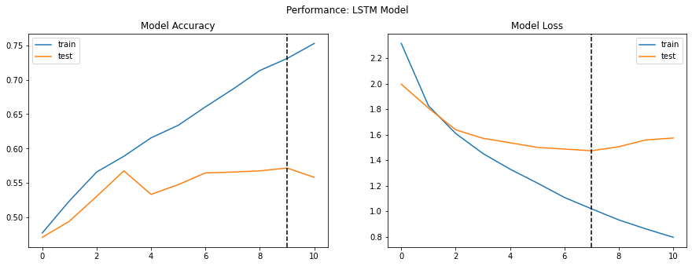

```python
import matplotlib.pyplot as plt
fig, (ax1, ax2) = plt.subplots(1,2,figsize=(15,5))
fig.suptitle("Performance: LSTM Model")
ax1.plot(history.history['accuracy'])
ax1.plot(history.history['val_accuracy'])
cut = np.where(history.history['val_accuracy'] == np.max(history.history['val_accuracy']))[0][0]
ax1.axvline(x=cut, color='k', linestyle='--')
ax1.set_title("Model Accuracy")
ax1.legend(['train', 'test'])

ax2.plot(history.history['loss'])
ax2.plot(history.history['val_loss'])
cut = np.where(history.history['val_loss'] == np.min(history.history['val_loss']))[0][0]
ax2.axvline(x=cut, color='k', linestyle='--')
ax2.set_title("Model Loss")
ax2.legend(['train', 'test'])
plt.show()
```

```python
import tensorflow
tensorflow.keras.backend.clear_session()
```

#### **LSTM merge model**

```python
model = Sequential()
model.add(Embedding(input_dim=num_words,
                        output_dim=embedding_size,
                        weights=[embedding_matrix],
                        input_length=maxlen,
#                       mask_zero=True,
                        trainable=False))
model.add(SpatialDropout1D(0.2))
model.add(Bidirectional(LSTM(100, dropout=0.2, recurrent_dropout=0.2), merge_mode="sum"))
model.add(Dense(100, activation='relu'))
model.add(Dropout(0.1))
model.add(Dense(74, activation='softmax'))
model.compile(loss='categorical_crossentropy', optimizer='adam', metrics=['accuracy'])
```

```
WARNING:tensorflow:Layer lstm will not use cuDNN kernel since it doesn't meet the cuDNN kernel criteria. It will use generic GPU kernel as fallback when running on GPU
WARNING:tensorflow:Layer lstm will not use cuDNN kernel since it doesn't meet the cuDNN kernel criteria. It will use generic GPU kernel as fallback when running on GPU
WARNING:tensorflow:Layer lstm will not use cuDNN kernel since it doesn't meet the cuDNN kernel criteria. It will use generic GPU kernel as fallback when running on GPU
```

```python
model.summary()
```

```
Model: "sequential"
_________________________________________________________________
Layer (type)                 Output Shape              Param #
=================================================================
embedding (Embedding)        (None, 656, 50)           733450
_________________________________________________________________
spatial_dropout1d (SpatialDr (None, 656, 50)           0
_________________________________________________________________
bidirectional (Bidirectional (None, 100)               120800
_________________________________________________________________
dense (Dense)                (None, 100)               10100
_________________________________________________________________
dropout (Dropout)            (None, 100)               0
_________________________________________________________________
dense_1 (Dense)              (None, 74)                7474
=================================================================
Total params: 871,824
Trainable params: 138,374
Non-trainable params: 733,450
_________________________________________________________________
```

```python
history_mode_sum = model.fit(X_train,
                    y_train,
                    epochs=25,
                    batch_size=batch_size,
                    validation_data=(X_test, y_test),
                    callbacks=[EarlyStopping(monitor='val_loss', patience=3, min_delta=0.0001)])
```

```python
acc_test =model.evaluate(X_test,y_test)
print("Test Accuracy:",acc_test[1])

acc_train =model.evaluate(X_train,y_train)
print("Train Accuracy:",acc_train[1])
```

```
Test Accuracy: 0.6000000238418579
Train Accuracy: 0.7055882215499878
```

```python
y_pred_mode_sum = model.predict(X_test)
```

```python
print('Classification report:\n %s' % (classification_report(y_test.argmax(axis=1), y_pred_mode_sum.argmax(axis=1))))
```

```
Classification report:
               precision    recall  f1-score   support

           0       0.68      0.89      0.77       761
           1       0.62      0.32      0.43        31
           2       0.53      0.33      0.41        63
           3       0.20      0.41      0.27        22
           4       0.10      0.05      0.07        19
           5       0.54      0.30      0.39        23
           6       1.00      1.00      1.00        15
           7       0.25      0.12      0.16        17
           8       0.31      0.10      0.15        40
           9       0.47      0.34      0.40        56
          10       0.76      0.78      0.77        64
          11       0.56      0.38      0.45        26
```

[output cut: 17 more lines]

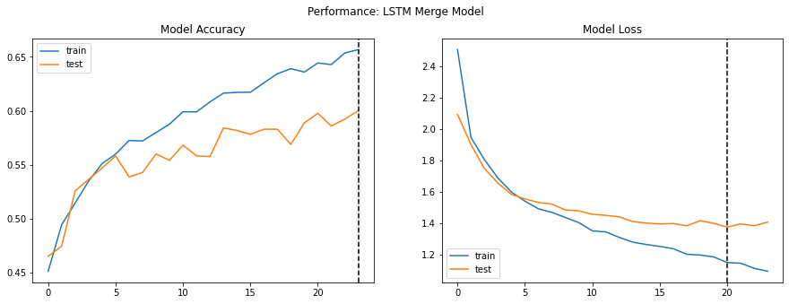

```python
fig, (ax1, ax2) = plt.subplots(1,2,figsize=(15,5))
fig.suptitle("Performance: LSTM Merge Model")
ax1.plot(history_mode_sum.history['accuracy'])
ax1.plot(history_mode_sum.history['val_accuracy'])
cut = np.where(history_mode_sum.history['val_accuracy'] == np.max(history_mode_sum.history['val_accuracy']))[0][0]
ax1.axvline(x=cut, color='k', linestyle='--')
ax1.set_title("Model Accuracy")
ax1.legend(['train', 'test'])

ax2.plot(history_mode_sum.history['loss'])
ax2.plot(history_mode_sum.history['val_loss'])
cut = np.where(history_mode_sum.history['val_loss'] == np.min(history_mode_sum.history['val_loss']))[0][0]
ax2.axvline(x=cut, color='k', linestyle='--')
ax2.set_title("Model Loss")
ax2.legend(['train', 'test'])
plt.show()
```

## Approach - 4 Oversampling Appraoch

To cater the problem of imbalance data, we have tried another approach of handle our minority class i.e. to up-sample them to make our distribution across target variable more balanced. There exist many oversampling techniques in the area of machine learning such as SMOTE (Synthetic Minority Over-Sampling Technique) or RandomOverSampler within imbalanced-learn package. Other techniques involve understanding the context of minority classes and creating sentences or jumbling or using key words from the data and generating new data. Other techniques involve understanding the context of the text in minority classes and generating text of same context or jumbling the words or identifying key words from the data and build synthetic data based on it. But since our most of the minority classes i.e. groups have only one entry compared to thousands of entries of majority class, these techniques might not result in efficient balancing of the data. We will be using below technique to oversample our data:

Random oversampling for the minority class

Random oversampling simply replicates randomly the minority class examples. Random oversampling is known to increase the likelihood of occurring overfitting. The increase in the number of examples for the minority class, especially if the class skew was severe, can also result in a marked increase in the computational cost when fitting the model, especially considering the model is seeing the same examples in the training dataset again and again.

```python
final_df= df2Ticketngrams[['LemmaString','Assignment group']]
final_df.head()
```

|  | LemmaString | Assignment group |
| --- | --- | --- |
| 0 | login verified details employee manager chec... | GRP_0 |
| 1 | outlook hmjdrvpb komuaywn hello team meeting... | GRP_0 |
| 2 | log vpn eylqgodm ybqkwiam hi best | GRP_0 |
| 3 | hr page | GRP_0 |
| 4 | skype | GRP_0 |

```python
from sklearn.preprocessing import LabelEncoder
df3 = final_df.copy()

df3['New group'] = LabelEncoder().fit_transform(df3['Assignment group'])
df3.head()
```

|  | LemmaString | Assignment group | New group |
| --- | --- | --- | --- |
| 0 | login verified details employee manager chec... | GRP_0 | 0 |
| 1 | outlook hmjdrvpb komuaywn hello team meeting... | GRP_0 | 0 |
| 2 | log vpn eylqgodm ybqkwiam hi best | GRP_0 | 0 |
| 3 | hr page | GRP_0 | 0 |
| 4 | skype | GRP_0 | 0 |

```python
df4 = df3[['New group','LemmaString']].copy()
```

```python
df4.head()
```

|  | New group | LemmaString |
| --- | --- | --- |
| 0 | 0 | login verified details employee manager chec... |
| 1 | 0 | outlook hmjdrvpb komuaywn hello team meeting... |
| 2 | 0 | log vpn eylqgodm ybqkwiam hi best |
| 3 | 0 | hr page |
| 4 | 0 | skype |

```python
max_features = 10000
embedding_size = 50
```

```python
def create_corpus(df):
    corpus=[]
    for desc in tqdm(df['LemmaString'].astype(str)):
        words=[word.lower() for word in word_tokenize(desc) if((word.isalpha()==1))] # & (word not in stop_words))]
        corpus.append(words)
    return corpus
```

```python
def create_inputvector(data,max_features,embedding_size,target):
  corpus = create_corpus(data)

  nb_words = []
  for i in range(len(data['LemmaString'])):
    nb_words.append(len(data['LemmaString'].iloc[i].split()))

  data['nb_words'] = nb_words
  print(data.columns)
  maxlen = max(data['nb_words'])

  tokenizer_obj=Tokenizer(num_words=max_features)
  tokenizer_obj.fit_on_texts(corpus)
  sequences=tokenizer_obj.texts_to_sequences(corpus)

  word_index = tokenizer_obj.word_index
  num_words = len(word_index)+1

  X = tokenizer_obj.texts_to_sequences(corpus)
  X = pad_sequences(X, maxlen = maxlen)
  y1 = data[target]
  y = to_categorical(y1, num_classes=74)
  return X,y,y1,maxlen,num_words
```

```python
X,y,y1,maxlen,num_words=create_inputvector(data=df4,max_features=max_features,embedding_size=embedding_size,target='New group')
```

```
Index(['New group', 'LemmaString', 'nb_words'], dtype='object')
```

### Performing OverSampling

```python
from sklearn.model_selection import train_test_split
from imblearn.over_sampling import RandomOverSampler

ROS = RandomOverSampler(sampling_strategy='auto', random_state=42)

x_res, y_res = ROS.fit_sample(X, y1)

for i in range(y1.unique().shape[0]-2):
  ROS = RandomOverSampler(sampling_strategy='auto', random_state=42)
  x_res, y_res = ROS.fit_sample(x_res, y_res)
```

```python
print ("Distribution of class labels before resampling {}".format(Counter(y1)))
print ("Distribution of class labels after resampling {}".format(Counter(y_res)))
```

[output not shown]

```python
y_res1 = to_categorical(y_res, num_classes=74)
```

```python
import tensorflow
tensorflow.keras.backend.clear_session()
```

```python
batch_size = 512
epochs = 5
```

```python
def LSTM_model(maxlen,batch_size,epochs):
  main_input = Input(shape=(maxlen,))
  em = Embedding(max_features, 100, input_length=maxlen) (main_input)

  lstm_out1 = LSTM(128, return_sequences = True)(em)
  lstm_out2 = LSTM(128)(lstm_out1)

  x = Dropout(0.2)(lstm_out2)

  main_output = Dense(74, activation = 'softmax')(x)

  model = tf.keras.Model(inputs = main_input, outputs = main_output)
  # compile the model
  model.compile(optimizer='adam', loss='categorical_crossentropy', metrics=['accuracy'])
  checkpoint = ModelCheckpoint("model-{loss:.2f}.h5", monitor="loss", verbose=1, save_best_only=True,
                               save_weights_only=True, mode="min", period=1)
  stop = EarlyStopping(monitor="loss", patience=5, mode="min")
  reduce_lr = ReduceLROnPlateau(monitor="loss", factor=0.2, patience=5, min_lr=1e-6, verbose=1, mode="min")
  print(model.summary())
  return model,checkpoint,stop,reduce_lr
```

```python
def plot_graph(history):
  fig, (ax1, ax2) = plt.subplots(1,2,figsize=(15,5))
  fig.suptitle("Performance: LSTM Model")
  ax1.plot(history.history['accuracy'])
  ax1.plot(history.history['val_accuracy'])
  cut = np.where(history.history['val_accuracy'] == np.max(history.history['val_accuracy']))[0][0]
  ax1.axvline(x=cut, color='k', linestyle='--')
  ax1.set_title("Model Accuracy")
  ax1.legend(['train', 'test'])

  ax2.plot(history.history['loss'])
  ax2.plot(history.history['val_loss'])
  cut = np.where(history.history['val_loss'] == np.min(history.history['val_loss']))[0][0]
  ax2.axvline(x=cut, color='k', linestyle='--')
  ax2.set_title("Model Loss")
  ax2.legend(['train', 'test'])
```

```python
skf = StratifiedKFold(n_splits=5,random_state=24, shuffle=True)
models, measures = [], []
for index, (train_indices, val_indices) in enumerate(skf.split(x_res, y_res)):
   ## Extract Kfold
  X_train_sfk, X_test_sfk = x_res[train_indices], x_res[val_indices]
  y_train_sfk, y_test_sfk = y_res[train_indices], y_res[val_indices]
```

```python
y_train_sfk = to_categorical(y_train_sfk, num_classes= 74)
```

```python
y_test_sfk = to_categorical(y_test_sfk,num_classes=74)
```

```python
model2,checkpoint2,stop2,reduce_lr2 = LSTM_model(maxlen=maxlen,batch_size=batch_size,epochs=epochs)
```

```
WARNING:tensorflow:`period` argument is deprecated. Please use `save_freq` to specify the frequency in number of batches seen.
Model: "model_3"
_________________________________________________________________
Layer (type)                 Output Shape              Param #
=================================================================
input_5 (InputLayer)         [(None, 656)]             0
_________________________________________________________________
embedding_4 (Embedding)      (None, 656, 100)          1000000
_________________________________________________________________
lstm_8 (LSTM)                (None, 656, 128)          117248
_________________________________________________________________
lstm_9 (LSTM)                (None, 128)               131584
_________________________________________________________________
dropout_4 (Dropout)          (None, 128)               0
_________________________________________________________________
dense_4 (Dense)              (None, 74)                9546
=================================================================
Total params: 1,258,378
Trainable params: 1,258,378
Non-trainable params: 0
_________________________________________________________________
None
```

```python
history2 = model2.fit(X_train_sfk, y_train_sfk, validation_data=(X_test_sfk,y_test_sfk), batch_size=batch_size, epochs=epochs, callbacks=[stop2,reduce_lr2])
```

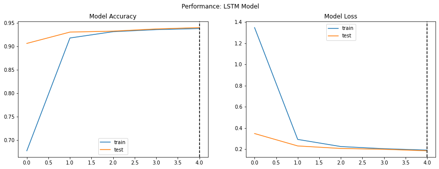

```python
plot_graph(history2)
```

```python
def print_scores(y_test,y_pred):
    print("Accuracy score: \n", accuracy_score(y_test,y_pred))
    print('Test-set confusion matrix:\n', confusion_matrix(y_test,y_pred))
    cm = confusion_matrix(y_test,y_pred)
    sns.heatmap(cm, annot=True, fmt='g')
    print("Classification report:" "\n", classification_report(y_test,y_pred))
```

```
Accuracy score:
 0.9400788525593093
Test-set confusion matrix:
 [[516   3   5 ...   0   7   3]
 [  0 795   0 ...   0   0   0]
 [  0   0 665 ...   0   0   0]
 ...
 [  0   0   0 ... 795   0   0]
 [  2   7   2 ...   0 445   0]
 [  0   0   0 ...   0   0 284]]
Classification report:
               precision    recall  f1-score   support

           0       0.95      0.65      0.77       795
           1       0.89      1.00      0.94       795
```

[output cut: 76 more lines]

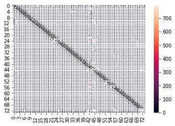

```python
y = model2.predict(X_test_sfk)
predictedClass = np.argmax(y,axis=1).tolist()
actualClass = np.argmax(y_test_sfk,axis=1).tolist()

tempDf_L12_AssignmentGroups = pd.DataFrame()
tempDf_L12_AssignmentGroups['ActualValue'] = pd.Series(actualClass)
tempDf_L12_AssignmentGroups['PredictedClass'] = pd.Series(predictedClass)
print_scores(tempDf_L12_AssignmentGroups['ActualValue'], tempDf_L12_AssignmentGroups['PredictedClass'])
```

#### **Learning from the approach**

- The accuracy is coming out to be really good reaching a satisfactory 94%. Oversampling the data and making the distribution more uniform has resulted in much better results.
- Precision and Recall has also come very good.
- F1 Score is also very good.
- As anticipated the computational cost has been increased significantly as well with each epoch running for nearly 1 hour

## **PERFORMANCE COMPARIOSN**

#### **LDA and word2vec**

| Models Incorporated | AUC-ROC Score |
| --- | --- |
| Logistic Regression | 0.59 |
| Random Forest | 0.84 |

#### **ML Approach**

| Models Incorporated | Train Accuracy | Test Accuracy |
| --- | --- | --- |
| Naive Bayes | 59% | 50% |
| Support Vecto Machine | 75% | 61% |
| Grid Search CV | 79% | 61% |

#### **Deep Learning Approach**

[output not shown]

#### **OverSampling**

| Models Incorporated | Train Accuracy | Test Accuracy |
| --- | --- | --- |
| LSTM(128)->LSTM(128)->Dropout->Dense | 93.78% | 94.01% |

## **FINAL SOLUTION**

Accordingly, we decided to submit the LSTM model with up-sampled data to be our final model for submission as the model is not over-fitting and is providing high train and validation accuracy as 93.78 % and 94.01%, respectively. As part of the preprocessing step we will be including the step to oversample out data using random over sampler and create more samples of the minority class

## **LIMITATIONS**

• The dataset is highly imbalanced considering our target variable which could affect the performance measurement criteria of our classification model.

• Handling of multiple language data and junk characters.

• The ‘langdetect’ and ’googletrans’ library works much better for longer strings where it can sample more n-grams. For short strings of a few words, it's not quite reliable.

• Language is detected more correctly for English and German but quite incorrectly for other languages.

• Adding caller to input feature was not adding significant improvement so we have assumed that the ‘Caller’ attribute does not include valuable information.

• Even though, the submitted model (oversampling approach) has high accuracy, it is taking too much time to train. The model can be upgraded to run faster, almost in real-time or near real-time or saving the model weights and using it through transfer learning.

## **CLOSING REFLECTIONS**

The journey from beginning to the submission of the Capstone Project has been very educative. Being the real-world problem, it seemed very difficult at the beginning to solve the problem as we struggled a lot in achieving desirable accuracy of the model which can be put in real world. During the journey of achieving the milestones, we have learned many new NLP techniques which are actually used in real-world problem-solving processes.

As we came across some mandatory steps to be followed in Text Processing, we can directly start with the same in next project, which can save a lot of time. Further, we can work towards reducing latency in the present model.

For next time, we may start with unsupervised techniques like clustering and build clusters out of data and try to learn the ground truth by building models on top of it.

We may try different libraries such as BERT next time which we have not used at this time to achieve the milestone. Also, for dealing with multi language data, since google translate was not giving satisfactory results, a more custom based translation system could be needed. For oversampling, more methods could be explored or business tailored system could be built for data synthesis. We would explore more hyperparameters and how they could affect the performance.

Overall, the experience has been very intuitive and full of learning and gives a snippet of real-world idea.